# Cognitive Psychology and Its Implications.Anderson2010.7e.认知心理学及其启示

### 用fMRI研究解方程

大多数脑成像研究着眼于相对简单的认知任务，大多数认知神经科学的研究也是如此。认知神经科学兴起的一个潜在风险是，人们可能会以为人脑只能处理那些可以用神经科学的技术来研究的简单事情。然而，现在已经有了一些考察较复杂过程的开创性尝试，并取得了相当可喜的成果。我将介绍一项我们所做的研究（Qin，Anderson，Silk，Stenger，& Carter，2004），这项研究考察了正在学习解方程的11～14岁的儿童的解方程过程。它体现了信息加工分析和认知神经科学技术的有效结合。

秦等人（Qin et al.，2004）研究了八年级学生解决三种不同复杂水平的方程的过程。复杂水平由求解所需变换的步骤数目来衡量：

0步：1x ＋0＝4

1步：3x ＋0＝12或1x ＋8＝12

2步：7x ＋1＝29

请注意：0步方程的形式与通常的不同，它在x前面有1，在x后有＋0。这种格式反映出这样一个事实：必须对不同条件下的视觉复杂性加以控制，以避免只是由于必须处理更为复杂的视觉刺激而在视觉皮层及其他地方获得差异。扫描时，学生们的头部要保持不动。他们戴着一只作反应用的手套，通过按下某一个手指来表明对该问题的回答（拇指＝1，食指＝2，中指＝3，无名指＝4以及小拇指＝5）。 <sup>(12)</sup>

秦等人（Qin et al.，2004）建立了一个解这种方程的信息加工模型，其中包括想象方程变换、算术和代数知识的提取以及动作反应的安排。图1.14表示了这些活动的序列。与已有的研究相一致，它有如下假设：

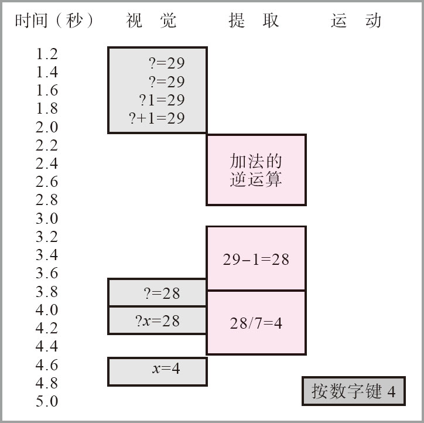

图1.14 求解方程7x＋1＝29的信息加工模型中的步骤。模型包括想象方程变换（视觉加工），算术和代数知识的提取，以及动作反应安排。

1. 手动安排反映在左侧运动皮层和躯体感觉皮层的激活（参见图1.10，被试用他们的右手作答，因此激活左侧大脑皮层）。
2. 每个方程的想象变换将激活顶叶皮层参与心理表象的区域（参阅第4章）。
3. 算术信息的提取将激活左前额皮层的一个区域（参阅第6章和第7章）。

图1.15示出了这三个感兴趣区域的部位。每个区域是一个边长约15毫米的立方体，大小大约是你手指的最后一节。fMRI能够有高得多的空间分辨率，但是我们的应用并不需要这种水平的精度。

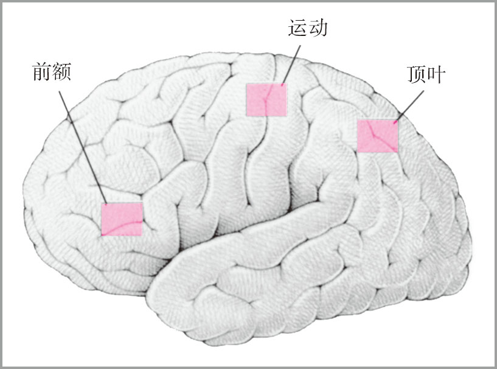

图1.15 方程求解实验中fMRI扫描的感兴趣区域。想象方程变换将激活左顶叶皮层的一个区域；算术信息提取将激活左前额皮层的一个区域；手动安排将激活左运动皮层和躯体感觉皮层。

解这三种类型方程的时间分别为：0步方程需2秒，1步方程需3.6秒以及2步方程需4.8秒。然而，在学生们按下手指给出答案以后，有一段长的休息时间以便让脑的活动水平返回至基线水平，接着进行下一次测试。秦等人（Qin et al.，2004）得到的数据是血氧水平依赖（BOLD）响应 ［blood oxygen level dependent（BOLD）response］超过基线的百分数。在这项实验中，每个区域每1.2秒记录一次BOLD响应数据。图1.16a显示了三种不同条件下运动区的BOLD响应。图中增量百分数从方程呈现时开始标示。请注意，即使学生们解0步方程并按键给出答案的平均时间为2秒，BOLD函数直到方程呈现后 <sup>(13)</sup> 的第3次扫描才开始上升到基线以上，直到大约6.6秒后它才达到峰值。这个结果反映了这样一个事实：由于氧合血液流到脑的相应部位需要花费时间，神经活动的血液动力学响应是有所滞后的。大体上，血液动力学响应达到峰值是在一次事件的4至5秒以后。在运动区（参见图1.16a），BOLD响应达到峰值的时间在解0步方程时大约为6.6秒，1步方程大约为7.8秒，2步方程大约为9.0秒。因此，最大值的点反映的是在大约4至5秒前发生的事件。

BOLD函数的峰使人们能读解脑（read the brain）和看到脑活动发生的时间。函数的峰值高度反映出所发生的活动的量。请注意，图1.16a中三种条件下的函数具有几乎相同的高度，这是因为每种条件下，按手指所需的精力相同，而与解方程变换次数无关。

图1.16b显示了三种条件下顶叶区的BOLD响应。如同在运动区，这些响应在不同的时间点达到峰值，这反映出解方程所花的时间不同。然而，它们达到峰值较运动区要早一些，这是因为这里的BOLD响应反映的是对方程的心理表象作变换，因而早于得到答案后的按键反应。并且，这里的BOLD函数达到的高度非常不同，反映出解方程所需执行的变换次数不同。图1.16c显示了前额叶区的BOLD响应，它与顶叶区的响应非常相似。重要的区别在于，在0步条件下函数没有上升，这是由于在此条件下无须提取任何信息。学生们从原始方程的心理表征就能读出答案。

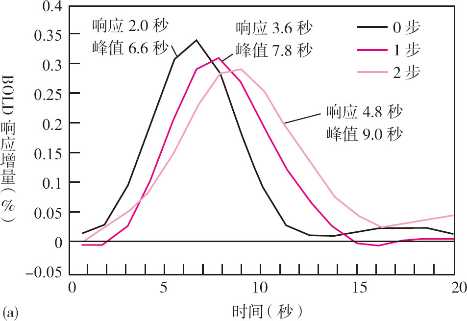

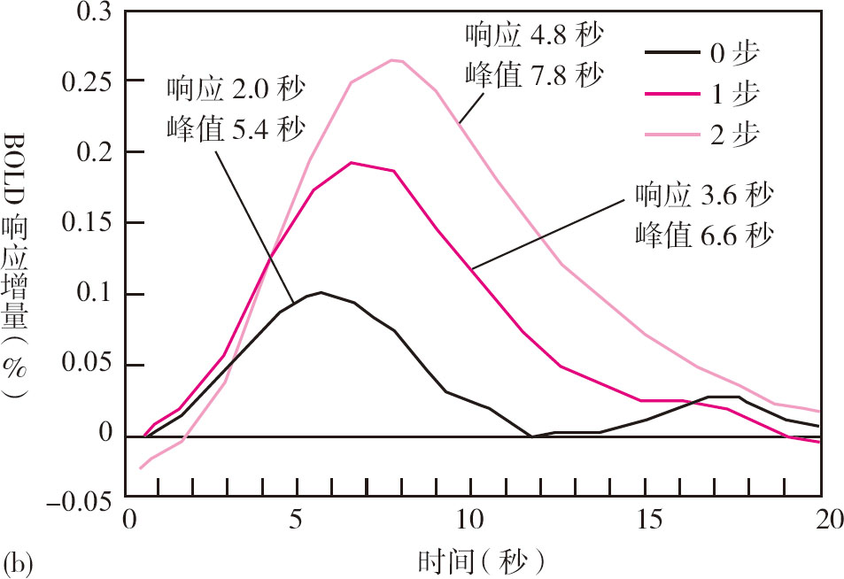

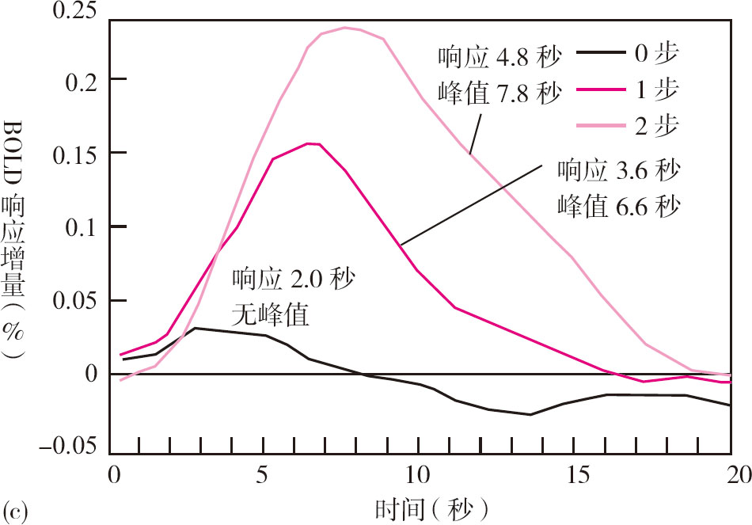

图1.16 图1.15中所示的感兴趣区域对不同方程复杂性的响应：（a）运动区；（b）顶叶区；（c）前额叶区。

这个实验表明，研究者能够分别追踪一项复杂任务执行过程所涉及的不同的信息加工成分。fMRI方法特别适合于复杂认知的研究。它的时间分辨率不是太好，因此，用来研究诸如斯滕伯格任务（参见图1.1和1.2）那样非常短暂的任务是困难的。而在另一方面，当人们在研究一项耗时许多秒的任务时，有可能将它所涉及的各信息加工过程的时间区分开来，正如我们在图1.16中见到的那样。由于它的高空间分辨率，fMRI能将整个加工过程的不同成分分离出来。对于简单的认知，ERP通常是更合适的脑成像技术，因为它能得到精确得多的时间分辨率。

◎fMRI能使研究者追踪一项复杂任务的不同信息加工成分的脑活动。

### 思考题

本书的网站 <sup>(14)</sup> 上为每章提供了一系列思考题（见Learning Objectives以及FAQ）。这些问题有助于进行有效的反思——即本章介绍过的PQ4R法的反思阶段。本书各章本身也提供了一系列问题用于强调这一部分的核心内容。本章的思考问题如下：

1. 认知心理学研究被描述为心理在研究心理本身。这真的是认知心理学家在如图1.1和1.16所示的研究中所做的事情的准确特征吗？认知心理学家研究他们自身的思维加工过程会带来特殊的机遇或挑战吗？科学家研究记忆这样的心理系统和研究消化这样的生理系统有什么不同吗？
2. 科学研究方法论中的还原论试图将一个水平的现象还原到较低的水平。例如，本章讨论了复杂的经济行为如何能够还原为个体的决策（认知），后者又如何能够还原为人脑中各个神经元的活动。然而，还原论并未止步于此。神经元的活动还可以还原到化学水平，而化学水平又可以还原到物理水平。通过较低的水平来理解较高的水平在什么情况下是有益的，在什么情况下是无益的？为什么按还原论程序一直进行下去，并且试图去用粒子物理学来解释经济行为这样的事情是无意义的？
3. 就其突出的智力功能而言，人类经常被认为优于其他动物。人类在哪些方面表现出这种质的优越性？在将其他动物研究的结果推论到人类身上时，这些方面会如何导致出现问题？
4. 新的脑活动成像技术已经对认知心理学研究产生了重大的影响，但是每种技术都有其局限性。这些技术的局限性分别是什么呢？理想的脑成像技术应该具备哪些特性？那些真正深入脑的研究（几乎只存在于非人类研究中）是如何为脑成像技术的使用提供信息的？
5. 在进行人类和非人类研究时有哪些伦理道德上的限制？

### 关键术语

认知心理学

人工智能

经验主义

先验主义

内省法

行为主义

格式塔心理学

语言学

信息加工法

斯滕伯格范式

认知神经科学

神经元

树突

轴突

突触

神经递质

兴奋性突触

抑制性突触

动作电位

放电频率

脑回

脑沟

枕叶

顶叶

颞叶

额叶

前额叶皮层

海马

基底神经节

胼胝体

裂脑病人

布罗卡区

威尔尼克区

失语症

拓扑组织

脑电图

事件相关电位

脑磁图

正电子发射断层扫描

功能性磁共振成像

血流动力学反应

经颅磁刺激

血氧水平依赖响应

(1) 韦斯伯格（Weisberg，1986）得出了类似的结论。

(2) 原文是individuals，不是指单个个人，而是指若干个个人。——译者注

(3) 又译为完形心理学。——译者注

(4) 神经系统中并非大多数细胞是神经元，还有许多其他的细胞，譬如，据信是为神经元提供支持的胶质细胞（glial cell）。

(5) 例如，根据一种观点，每个神经元每10毫秒执行上千次的实数乘法和加法运算。

(6) ASCII是美国信息交换标准码（American Standard Code for Information Interchange）的缩写。表1.1的上方是词cognitive的ASCII码，下方是词psychology的ASCII码。其中上方第1列是字母c 的ASCII码，第2列是字母o的ASCII码，依此类推。

(7) 患者将turnpike说成了purnpike。

(8) 非正确英语单词。

(9) 非正确英语单词。

(10) 为了方便起见，这里用了音译。但需要说明，著者在email中指出，这里的topographic与用在其他地方的topology（拓扑）、topography（地形图）无密切关联。它是指，如同在初级运动皮层或初级视觉皮层中那样，空间中相邻的部分在脑中表达在相邻的部位。按照语义应当译成“近邻保持组织”。——译者注

(11) 通常一个实验由许多次测试（trial）组成。——译者注

(12) 所有方程的解全都用心算求得，实验所用方程的解只在1到5的范围之内。

(13) 原文为‘方程解出后’，有误。——译者注

(14) 网址为http://bcs.worthpublishers.com/anderson7e/，出版社（不是本书作者）为本书英文原版书的学习者提供了免费的学习辅助材料。——译者注

# 第2章 知觉

我 们的身体布满了各种感受器以觉察光线、声音、气味以及与身体的接触。几十亿个神经元对感觉信息进行加工，并将其所发现的信息传递至脑的更高级的中心。这个庞大的信息加工系统给高级认知带来了一个问题，即：如何从所有加工过的感觉信息中选出需要注意的信息，本书第3章将讨论这个问题。本章将集中在感觉系统如何识别我们自身以外的世界。我们将主要阐述视知觉，其次是言语知觉，这是人类最重要的两个知觉系统。

本章将着重介绍以下问题：

- 人脑如何从视觉信号中提取信息？
- 如何将视觉信息整合成客体？
- 如何识别视觉和言语模式？
- 背景如何影响模式识别？

## 视觉信息加工

### 脑的视知觉

图2.1所示的是与加工视觉和听觉信息有关的皮层区域。从图中可以清楚地看到，人类投入了大量的神经资源来加工视觉信息。这种视觉上的投入是我们作为灵长类而“继承”下来的，经过进化灵长类50％的脑都用于视觉加工（Barton，1998）。人脑的大量的视觉信息加工是人类能识别所看到的东西的基础。

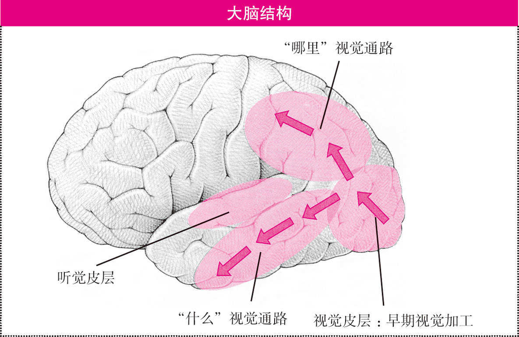

图2.1 部分与视觉和听觉加工有关的皮层结构：视觉皮层、听觉皮层、“哪里”视觉通路以及“什么”视觉通路。 （Ungerleider & Mishkin，1982）

特定脑区的损伤有时会导致一个人能获取视觉信息，但是不能识别它们。视觉失认症 （Visual agnosia）是一种既不是由一般智力受损、也不是由基本的感觉能力受损而导致的物体识别能力的丧失。有一名士兵由于意外的一氧化碳中毒导致脑损伤而成为视觉失认症病人。他能通过触觉、气味或声音来识别物体，但他不能将正方形与圆形区分开来，也不能识别脸或字母（Benson & Greenberg，1969）。另一方面，他能区分光的强度和颜色，也能说出物体移动的方向。因此，他的感觉系统能够记录视觉信息，但是，脑损伤使他丧失了将视觉信息转变成知觉经验的能力。这个病人的个案表明，知觉远不止是将感觉信息记录下来。

一般来说，视觉失认症可分为统觉失认症 （apperceptive agnosia）和联想失认症 （associative agnosia）（综述可参阅Farah，1990）。本森（Benson）和格林伯格（Greenberg）的病人被认为患有统觉失认症。这种病人不能识别如圆形或三角形等简单的图形，或者不能画出所呈现的图形。而联想失认症病人能够识别简单的图形，甚至也能临摹出复杂的物体。但是他们不能识别复杂的物体。图2.2为一个船锚的原图和由一名联想失认症病人临摹的图（Ratcliff & Newcombe，1982）。尽管这位病人能够画出一幅相对准确的图画，但是他却不能识别出该物体是一个船锚，而说这是一把伞。一般认为，统觉失认症病人的视觉系统在早期信息加工中存在问题，联想失认症病人的早期加工完好，但他们在后来的模式识别上存在困难。人们经常会区分视觉流中信息的早期加工和晚期加工，这种区分也是本章的组织原则之一。

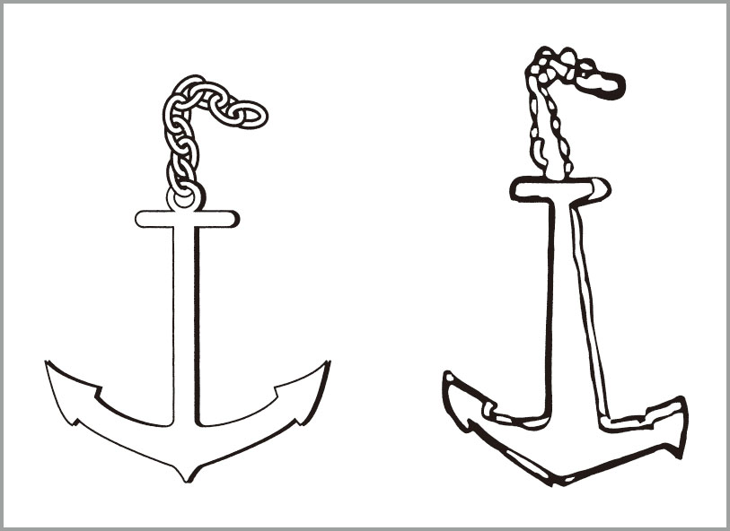

图2.2 一个联想失认症病人能临摹左侧的船锚原图（病人的画位于右侧），但是他不能识别出该物体是船锚。 （资料来源：Ellis & Young，1988．Reprinted by permission of the publisher．© 1988 by Quarterly Journal of Experimental Psychology.）

图2.3为具有正常视知觉的人提供了一个体验早期与晚期视觉加工之间区别的机会。如果你以前没有看过这幅图，你会猛然觉得这只是一大片墨迹的斑点。你能判断出各种不同斑点的大小并将它们画出来，正如拉特克利夫和纽科姆的病人所能做的那样，但你看不到任何模式。然而，如果你一直盯住这幅图，你会突然发现图片的中央有一只狗。现在，你的模式知觉成功了，你对你所看到的东西进行了解释。本章我们将先讨论在模式识别前视觉信息如何进行加工，然后再讨论模式识别。

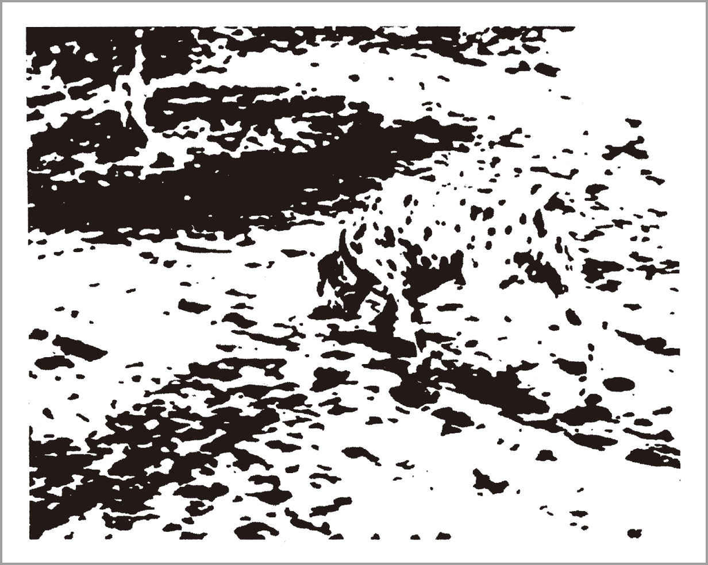

图2.3 一幅景象图。最初，我们只是看到低层次的视觉细节（斑点）；只有经过长时间凝视，一只狗的形象才会显现出来。 （Courtesy of Ronald James.）

◎视知觉可以分为早期阶段和晚期阶段，在早期阶段将图形和物体从视觉景象中提取出来，在晚期阶段则对图形和物体进行识别。

### 早期视觉信息加工

我们已经对早期视觉信息加工的神经基础有了相当的了解。图2.4为眼的示意图。光线穿过晶状体和玻璃体投射到位于眼后部的视网膜上。视网膜含有光感受器细胞，这些细胞由对光敏感的分子组成，当暴露在光照之下时这些分子会发生结构性的变化。光线在穿过玻璃体时会产生轻微的散射，因此落在视网膜背面的图像并非极其清晰。早期视觉加工的功能之一是锐化图像。

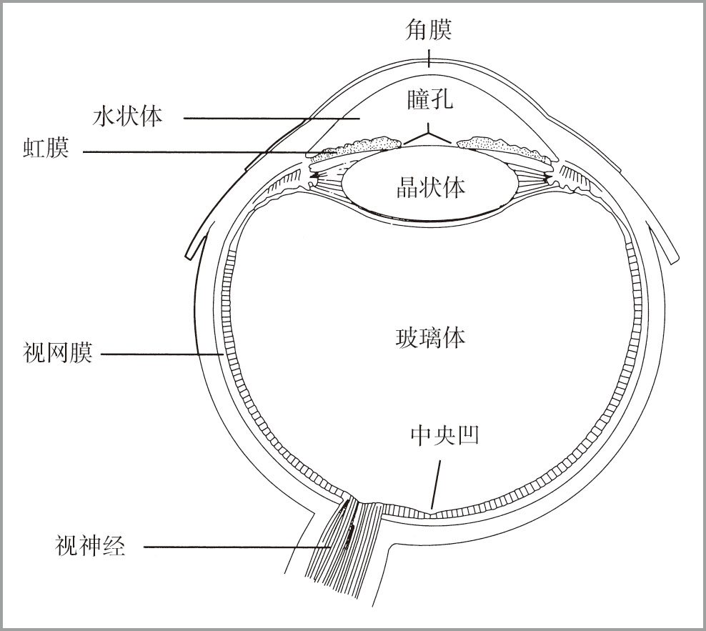

图2.4 眼的示意图。光线经角膜进入眼内，通过水状体、瞳孔、晶状体和玻璃体，然后照射和刺激视网膜。 （资料来源：Lindsay & Norman，1977．Reprinted by permission of the publisher．© 1977 by Academic Press.）

光化学作用将光能转换成神经能。眼睛内有两种不同的光感受器：视锥细胞和视杆细胞。视锥细胞参与颜色视觉，具有高分辨率和高视敏度。视杆细胞能对较弱的光能进行反应，但是它们只具有较低的分辨率。这样，视杆细胞主要负责我们在黑夜所体验到的不够敏锐的黑白视觉。视锥细胞主要聚集在一个被称为中央凹 （fovea）的视网膜的小区域内。当我们注视某个物体时，我们会移动自己的眼球以使这个物体落在中央凹上。这使我们在感知该物体时能最大限度地利用视锥细胞的高分辨率。中央凹觉察细节，而其余的视觉区域——周边视觉区域则察觉比较全局性的信息，包括运动信息。

感受器细胞与两极神经细胞形成突触，两极细胞与神经节细胞相连，神经节细胞的轴突延伸并构成通向脑的视神经。每一只眼睛的视神经中总共约有80万个神经节细胞。每个神经节细胞对来自视网膜的一小块区域的信息进行编码。神经节轴突上的神经脉冲通常是对视网膜上相应区域内的光刺激量的编码。

图2.5显示了从眼到脑的神经通路。来自双眼的视神经在视交叉处汇合，而来自视网膜内侧（靠近鼻子的一侧）的视神经彼此交叉，然后通向脑的对侧。来自视网膜外侧的神经则继续延伸至与双眼同侧的脑部。这意味着双眼的右半部分与右脑半球相连。如图2.5所示，晶状体将光线聚焦，使得左侧视野进入每只眼的右半部。因此，有关左侧视野的信息传递至右脑，而有关右侧视野的信息传递至左脑。这是在第1章中讨论过的左脑半球加工外界右侧部分的信息，而右脑半球加工外界左侧部分信息的一个例子。

一旦进入脑的内部，来自神经节细胞的神经纤维就与各种皮层下结构的细胞形成突触。（皮层下结构位于大脑皮层之下。）这些皮层下神经结构包括外侧膝状体和上丘（见图2.5）。人们认为，外侧膝状体在觉察细节和辨识物体方面有重要作用，而上丘则参与对物体的空间定位。这种区分被称为“什么—哪里”的分工。这两种神经结构都与初级视皮层相连（彩色插图1.1中的布罗德曼17区）。初级视皮层是首先接受视觉输入的皮层，但是周围还有很多其他的视觉区域，包括布罗德曼18区和19区。

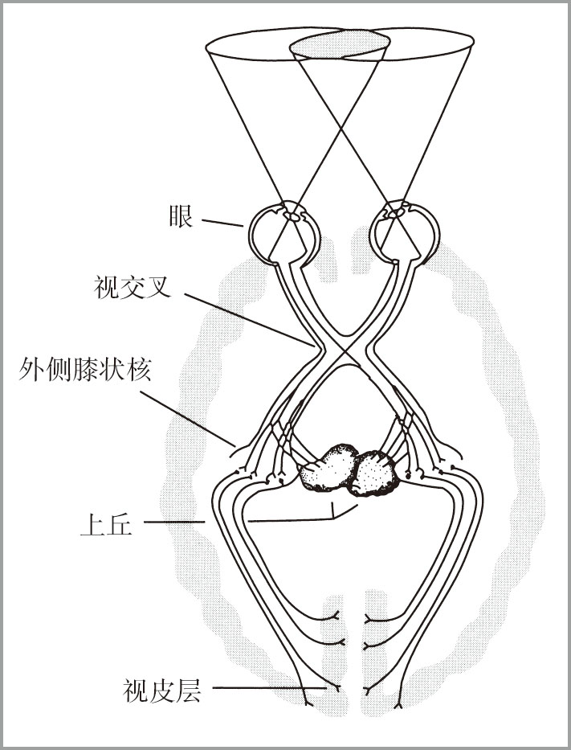

图2.5 从眼到脑的神经通路。来自每只眼的视神经在视交叉处汇合。左侧视野的信息传递至右脑，而右侧视野的信息传递至左脑。视神经纤维与皮层下结构（例如外侧膝状体和上丘）的细胞形成突触。这两种神经结构都与视皮层相连接。 （资料来源：Keeton，1980．Reprinted by permission of the publisher．©1980 by W．W．Norton.）

图2.6所示的是视觉世界在初级视皮层上的表征。图中可以看到，视觉皮层就像第1章所讨论的那样呈拓扑结构分布。中央凹拥有超大比例的表征，而外围区域的表征却较少。图2.6显示出左视野表征在右侧皮层上，而右视野表征在左侧皮层上。我们还可以看到另一种“反转”映射——上方视野表征在皮层下部，而下方视野表征在皮层上部。

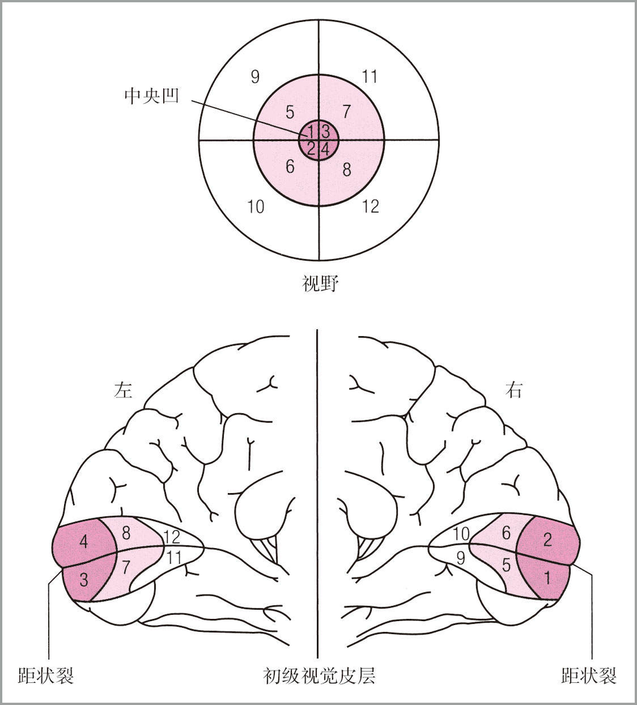

图2.6 视野（上图）按顺序映射在皮层上。上方的视野映射在距状裂的下面，下方的视野映射在距状裂的上面。注意视觉最敏锐的区域中央凹，占据了超大的对应区。 （资料来源：Figure 29-7 in Kandel et al.，1991）

如图2.1所示，视觉信息投射到初级视皮层后，它往往会沿着两条通路进行传导。沿“哪里”通路行进的信息传递至顶叶的脑区，这些脑区专门负责空间信息以及视觉与动作的协调。沿“什么”通路行进的信息传递至颞叶，颞叶涉及对物体的识别。“哪里”通路受损的猴子难以学会识别特定位置，而“什么”通路受损的猴子难以学会识别物体（Pohl，1973；Ungerleider & Brody，1977）。其他研究者（例如Milner & Goodale，1995）认为，“哪里”通路其实主要负责动作。他们指出，顶叶完好而颞叶受损的失认症病人，经常能够对他们所不能识别的物体采取恰当的行动。例如，一位病人（参见Goodale，Milner，Jakobson，& Carey，1991）能够准确地将手伸向她不能识别的门把手并且握住它。

◎光化学过程将光能转化为神经活动。视觉信息经由各种神经通路传导至视皮层，再从视皮层沿“什么”与“哪里”通路通过大脑。

### 视细胞中的信息编码

库夫勒（Kuffler，1953）的研究揭示了信息是如何被神经节细胞编码的。即使眼睛没有接受到任何光线，这些细胞通常也会以某种频率进行自发性的放电。对某些神经节细胞来说，如果光线落到视网膜的某一个小区域上，这些自发性的放电频率会增加。但是，如果光线落到该感觉中心的周围区域上，自发放电的频率会降低。而落到距离中心太远的区域的光不会引起自发放电频率的变化，即既不增强也不减弱。以这种方式做出反应的神经节细胞被称为开—闭细胞，还有闭—开神经节细胞：落在感觉中心处的光线会降低自发放电的频率，而落在周围区域的光线会增加频率。外侧膝状体细胞也有这两种反应方式。图2.7表示这些细胞的感受野。

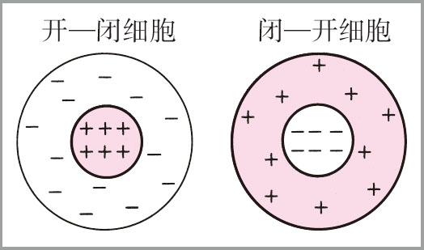

图2.7 神经节细胞和外侧膝状体细胞的开—闭和闭—开感受野。

休布尔和威塞尔（Hubel & Wiesel，1962）在对猫的初级视皮层的研究中发现，初级视皮层细胞的反应方式比神经节细胞和外侧膝状体细胞更为复杂。图2.8显示了在皮层细胞中观察到的四种模式。这些感受野都是长条形的，而不是开—闭细胞和闭—开细胞的圆形感受野。图2.8a和2.8b中所示的类型为边缘觉察器 （edge detectors）。它们对投射到直线一侧的光线作正反应，而对投射到其另一侧的光线作负反应。如果投射光的边缘刚好落在边界线上，它们的反应最强。图2.8c和2.8d的类型是直条觉察器 （bar detectors）。它们对投射到中心处的光线作正反应，而对投射到其外围的光线作负反应，或者与此相反。因此，正中心的直条觉察器细胞的中心如果刚好被条状的光线覆盖，那么它的反应最强烈。图2.9所示的是一群开—闭细胞或闭—开细胞联合起来组成的直条或边缘觉察器。注意，单个细胞不足以使一个觉察器兴奋；觉察器对应着特定模式的细胞组合。即使在这种低水平上，我们也能看到神经系统根据神经活动的模式来加工信息，而这正是第1章强调的一个主题。

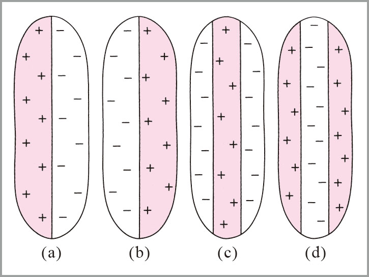

图2.8 视皮层细胞的反应模式，（a）和（b）是边缘觉察器，它们对投射到直线一侧的光线作正反应，而对投射到另一侧的光线作负反应。（c）和（d）是直条觉察器，它们对投射到中心处的光线作正反应，而对投射到外周处的光线作负反应，或者对投射到中心处的光线作负反应，而对投射到外周处的光线作正反应。

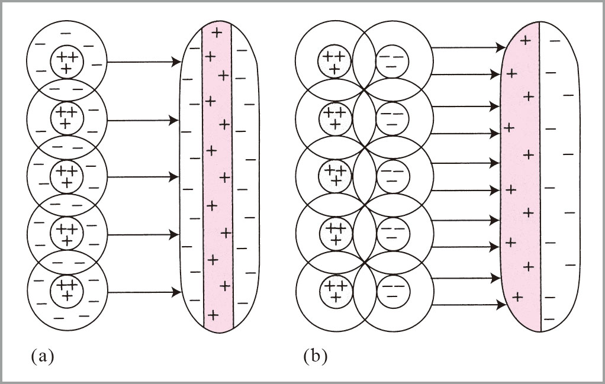

图2.9 构成（a）直条觉察器和（b）边缘觉察器的开—闭细胞和闭—开细胞的假设性组合。

直条和边缘觉察器都与位置、方向及宽度有关。也就是说，它们只对很小视野区域的刺激、很小方向范围的直条和边缘、特定宽度的直条和边缘做反应。然而，不同的觉察器似乎对应着不同的宽度和方向，因此，一些直条觉察器的集合有可能会对视野内某些直条或边缘做出最强烈的反应。

图2.10显示了休布尔和威塞尔（1977）的初级视皮层中细胞的超柱表征。他们发现，视皮层被划分为2×2毫米的区域，他们称这些区域为超柱。每个超柱表示感受野中的一个特定区域。正如第一章所指出的那样，视皮层的组织具有拓扑特征，因此视野中相邻的区域由相邻的超柱表征。图2.10表明每个超柱本身就具有二维（2-D）的组织。沿着一维的方向，各列交替接收来自左眼或右眼的输入。沿着另一维，细胞最敏感的方向发生变化。相邻的区域表征着相近的方向。这种组织应该使我们看到视觉阵列有多少信息被编码了。每只眼睛都有数百个空间区域被表征，在这些区域内有许多不同的方向被表征。此外，尽管图中没有显示这一方面，但不同的细胞将对不同的线条长度和宽度编码。因此，当视觉信号最初到达大脑皮层区域时，大量信息就已经被提取出来了。

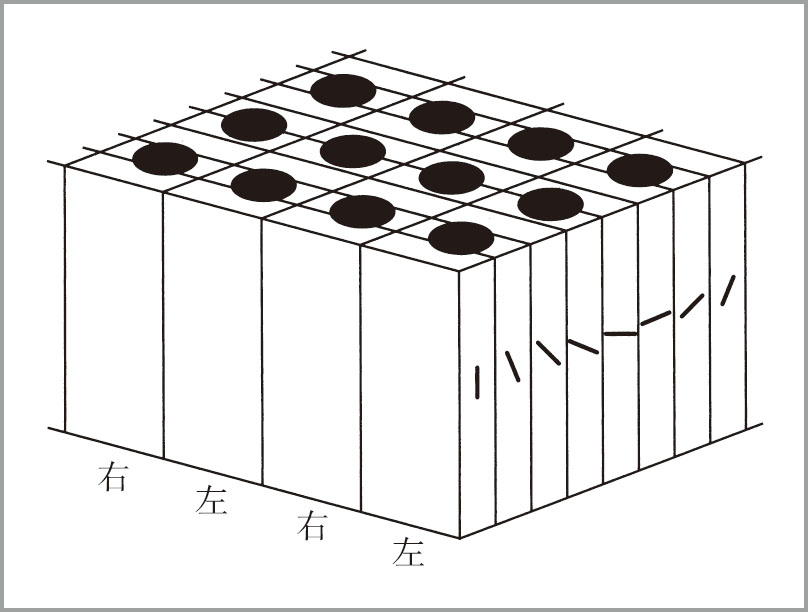

图2.10 视皮层中的超柱示意图。超柱的一维根据输入来自右眼还是左眼进行组织。在另一维上，超柱根据感受细胞最敏感的线条方向进行组织。相邻区域表征相近的方向。 （资料来源：Horton，1984．Adapted by permission of the publisher．© 1984 by the Royal Society of London）

除了对线条方向的有着丰富的表征外，视觉系统还从视觉信号中提取其他信息。例如，我们还能知觉物体的颜色以及它们是否在运动。利文斯顿和休布尔（Livingstone & Hubel，1988）认为，视觉系统对物体的不同维度（形状、颜色和运动）分别进行加工。许多不同的视觉通道和大脑皮层的许多不同区域都参与视觉加工［据范艾森和戴约统计（Van Essen & DeYoe，1995）有32个］。不同通路中有特异地对颜色、运动和方向敏感的细胞。视觉系统似乎将刺激分解成许多独立的特征，并且表征这些特征的位置。视觉特征的这种空间表征被称为特征地图 （fearure maps，Wolfe，1994）。因此，如果一根垂直的红色直条在某个特定的位置上移动，那么就会有不同的特征地图分别表征它是红色的、垂直的和在某个位置上运动，这些特征地图可能位于脑的不同视觉区。

◎神经节细胞通过开—闭细胞和闭—开细胞对视野进行编码，这些细胞通过高层次的视觉加工组合在一起形成各种特征。

### 深度与表面知觉

即使视觉系统已经识别出环境中的边缘和直条，在它能够知觉到外部世界之前，还必须进行大量的信息加工。必须解决的问题之一是，确定这些边缘和直条的空间位置。这里的根本问题是，投射在视网膜上的信息本身是二维的，而我们需要构建外部世界的三维（3-D）表征。视觉系统对大量线索进行加工以推断距离。这些线索之一是纹理梯度，它是指随着离观察者距离的增加，各个元素更紧密地聚在一起的趋势。图2.11所示的是吉布森（Gibson，1950）的经典例子，尽管这些线段和椭圆形被画在一张平铺的纸上，但是纹理上的变化体现出距离感。深度感知的另一线索是立体视觉，由于每只眼睛所接收到的外部世界的映像略有不同，所以具有感知3-D深度的能力。一些电影院以及类似迪斯尼乐园所举办的一些展览用的3-D眼镜都是立体视觉的应用。它们过滤了来自单个2-D光源（例如，电影屏幕）的光线，使得到达每只眼睛的光信息不同。由立体视觉导致的3-D结构知觉可以非常逼真。

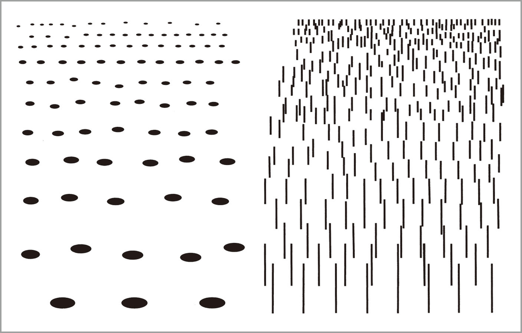

图2.11 纹理梯度的例子。图中的基本元素排列得越密集，看起来离得越远。 （资料来源：Gibson，1950．Reprinted by permission of the publisher．© 1950 by Houghton Mifflin.）

有关3-D结构的第三个信息源是运动视差。较远的点移动时，会比较近的点更慢地通过视网膜。与此类似，当一个人头部运动时，较远的物体会比较近的物体更慢地通过视网膜。有一个有趣的演示，闭上一只眼，观看近处的一棵树或一丛灌木的叶子。由于没有立体视觉信息，你将会感觉到一幅非常平面的图像，而难以看清许多树叶之间的相对位置。然后转动你的头，树的3-D结构突然变得清晰，你能真切地知觉到树叶和树枝的相对位置。

◎纹理梯度、立体视觉和运动视差等线索整合在一起，以生成三维空间中各表面位置的表征。

### 物体知觉

在计算外部世界表征时的一个主要问题是物体的分割。仅仅知道线段和直条在空间的位置还不够，我们还需知道它们如何集合在一起形成物体。请参见图2.12中的景象。其中有许多不同走向的线段，但是，我们能以某种方式将它们放在一起形成对一系列物体的知觉。

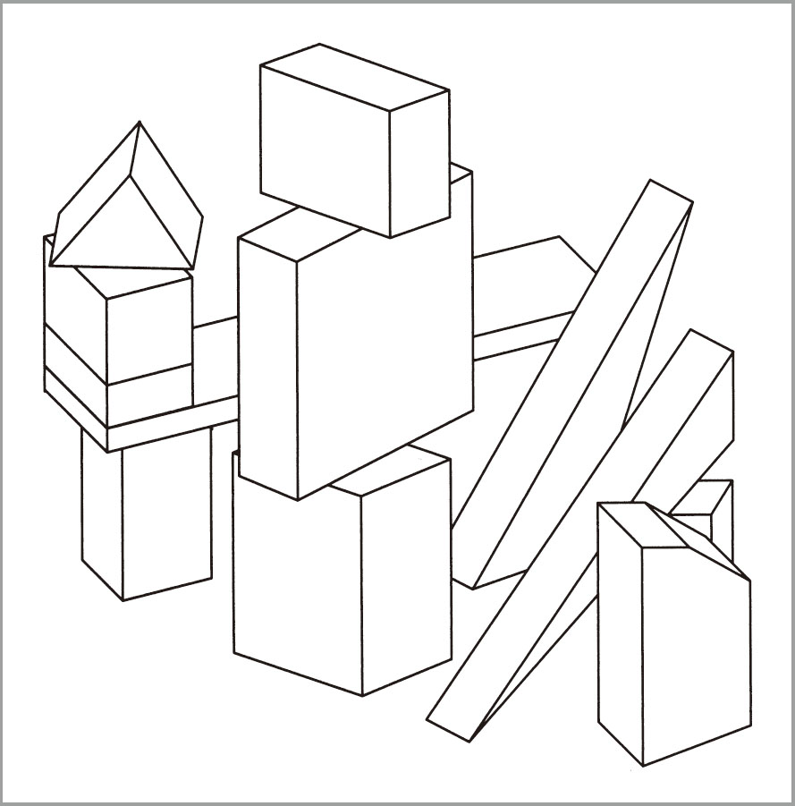

图2.12 我们如何将对许多线段的知觉整合为对若干立体物体的知觉的一个例子。 （资料来源：Winston，1970．Reprinted by permission of the publisher．©1970 by Massachusetts Institute of Technology.）

我们往往按照一系列原则将对象组织成单元，这些原则由格式塔心理学家（例如Wertheimer，1912/1932）最先提出并被称为格式塔组织原则 （gestalt principles of organization）。请看图2.13。在图2.13a中，我们看到4对平行线，而不是8条独立的线段。这张图说明了接近原则：相近的元素倾向于被组织成单元。图2.13b说明了相似原则。我们倾向于将这个矩阵看成是o行与x行的交替排列。看上去相像的物体往往被组合在一起。图2.13c说明了良好连续原则。我们知觉到两条曲线，一条从A到B，另一条从C到D。尽管没有理由能说明为什么不将这幅图知觉成另一对曲线，一条从A到D，另一条从C到B。但是，从A到B的曲线比起有一个尖锐拐点的从A到D的曲线具有更好的连续性。图2.13d说明了闭合及良好构形原则。我们看到的图是一个圆被另一个圆遮挡，尽管被遮挡的物体可能有许许多多的其他形状。

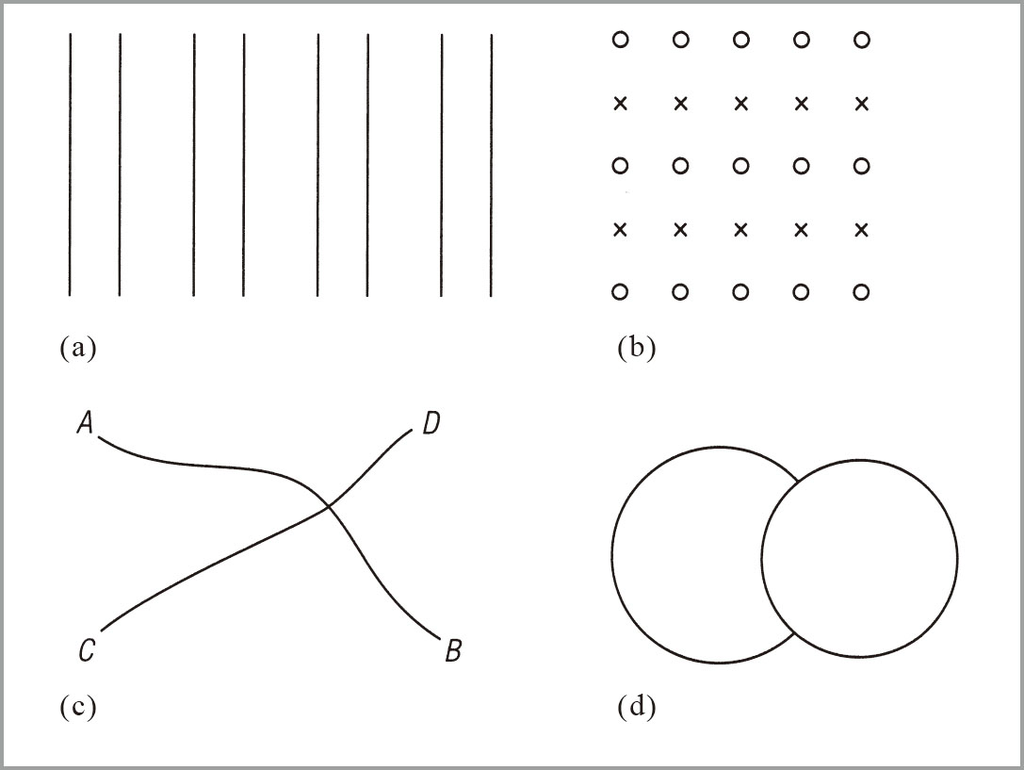

图2.13 格式塔组织原则的示意图：（a）接近原则，（b）相似原则，（c）良好连续原则，（d）闭合原则。

即使是完全新奇的刺激，我们也倾向于利用这些原则将它们组织成单元。帕尔默（Palmer，1977）研究了对如图2.14中所示的形状的识别。他首先向被试呈现刺激（例如，图2.14a），然后要求被试判断从图2.14b到2.14e的这些片断是否是原图的一部分。图2.14a中的刺激倾向于将自身组织成三角形（闭合原则）和弯曲的字母n （良好连续原则）。帕尔默发现，当片断符合格式塔原则时，被试对这些部分的识别非常快。因此，识别图2.14b和图2.14c中的刺激要比识别图2.14d和图2.14e中的刺激快。可见，识别的关键在于图形的初始分割。当基于格式塔的分割与实际的图形结构发生冲突时，识别就会变得困难。FoRiNsTaNcEtHiSsEnTeNcEiShArDtOrEaD。 <sup>(1)</sup> 感到困难的原因在于格式塔的相似原则导致难以将不同大小写的相邻字母看成单元，并且单词之间没有空格，也就消除了接近原则所需的线索。

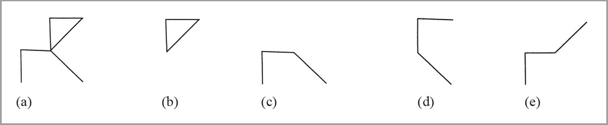

图2.14 帕尔默（Palmer，1977）研究新奇图形的分割时所采用刺激的例子。（a）为被试看到的原始刺激；（b）至（e）为需要识别的子成分刺激。识别（b）和（c）所示的刺激快于识别（d）和（e）所示的刺激。

这些有关分割的概念可以用来描述如何划分更复杂的3-D构造。图2.15是由霍夫曼和理查兹（Hoffman & Richards，1985）提出的如何用格式塔原则将一个物体的轮廓分割成子物体的方案。他们观察到当一个部分与另一个部分相连接时，在轮廓线图上通常有一个凹面。人们基本上运用了格式塔的良好连续原则：凹面上的轮廓线没有良好的连续性，因此观察者不会将它们组合在一起。

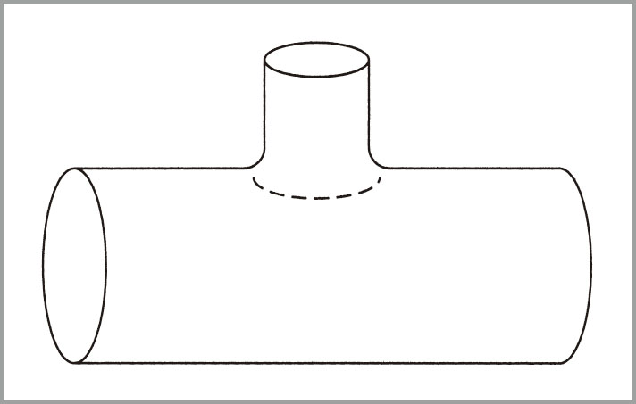

图2.15 将一个物体分割成多个子物体。子物体的边界可以根据最大凹面度的等高线（虚线）识别出来。 （资料来源：Stillings et al.，1987；based on Hoffman & Richards，1985．Reprinted by permission of the publisher．©1987 by Massachusetts Institute of Technology.）

当前的观点认为，以识别物体在三维空间的位置和形状的能力为基础的视觉加工很大程度上是与生俱来的。婴幼儿似乎就已经能够识别物体及其形状，并且能意识到物体在三维空间中的位置（例如，Granrud，1986，1987）。

◎格式塔组织原则解释了脑如何将视觉景象分割成各种物体。

## 视觉模式识别

对视觉信息加工的讨论已经谈到我们如何将视觉世界组织成客体。然而，要理解外部世界还要迈出重要的一步：我们还必须识别这些物体是什么。这项任务就是模式识别。关于该主题，大多数研究集中在我们如何识别字母这一问题上。例如，我们如何识别出字母A 的一个表征是模式A 的一个实例？我们将首先从字母识别来讨论模式识别，然后再转向更为一般性的物体识别。

### 模板匹配模型

或许最显而易见的模式识别方法是模板匹配 （template matching）。知觉的模板匹配理论认为，物体在视网膜上的影像如实地传到大脑，大脑则将这个图像直接与存储的各种模式进行比较。这些存储的模式被称为模板。其基本思想是，知觉系统将一个字母的图像与脑所存储的每个字母的模板进行比较，然后报告最佳匹配模板。图2.16给出了各种成功和不成功的模板匹配的例子。在每种情况下都试图使受到字母刺激的视网膜细胞与某种特定模板模式的视网膜细胞之间实现对应。

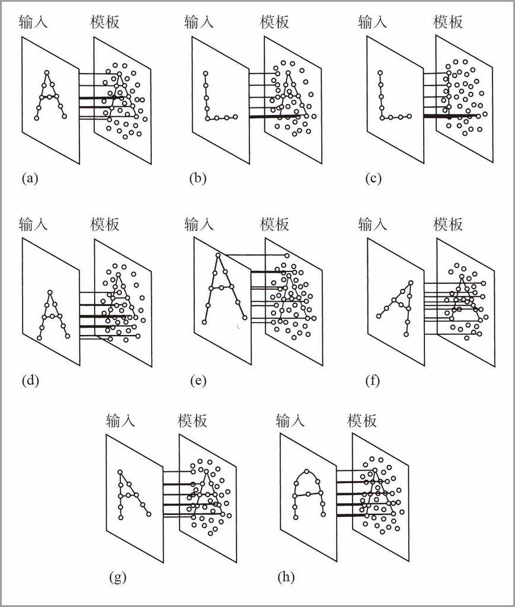

图2.16 试图使模板与字母A和L匹配的各种例子。（a）和（c）为模板匹配成功的例子；（b）以及从（d）到（h）均为模板匹配不成功的例子。 （资料来源：Neisser，1967．Adapted by permission of the publisher．©1967 by Appleton）

图2.16a是实现了对应，字母A 被识别的情况。图2.16b表示输入的L 与A 的模板之间不存在对应，而在图2.16c中L 与模板L 实现了匹配。但是使用模板非常容易出错。图2.16d表示当图像投射到视网膜的错误部位时匹配失败，而图2.16e表示图像大小出错时所出现的问题。图2.16f表示图像方向出错时所发生的情况，而图2.16g和图2.16h表示图像为非标准A 时所出现的困难。

尽管采用模板匹配存在许多问题，但是它仍然是机器视觉中所采用的方法之一（参见Ullman，1996）。人们已经开发出了用于匹配旋转、拉伸以及扭曲图像的程序。模板匹配也被应用于fMRI脑成像技术（见第1章）。每个人的脑在解剖结构上都是不同的，就好像每个人的身体都不同一样。当研究者说图1.15所示脑区表现出图1.16那样的激活模式时，他们是在说每个被试的同一个脑区都表现出了这种模式。为了确定是否是同一个脑区，他们要利用复杂的3-D模板匹配计算机程序，将每个个体的脑与一个参照脑进行比较。虽然模板匹配取得了一些成功，但是计算机利用模板匹配来进行模式识别的能力仍然有限。本章“启示”专栏中关于CAPTCHAs <sup>(2)</sup> 的介绍与此有关。

◎模板匹配是通过将刺激与模式的模板进行匹配来识别物体的一种方法。

### 特征分析

鉴于模板匹配遇到的困难，心理学家提出，模式识别是通过特征分析（feature analysis）实现的。在这个模型中，刺激被认为是基本特征的组合。引自吉布森（Gibson，1969）的表2.1给出了她提出的用于对字母表中的字母进行表征的特征。例如，大写字母A可以看做由如下特征组成：一条水平线，两条反方向的斜线，一个交叉，对称，还有一个被她称为垂直中断的特征。她认为像直线这样的一些特征是视觉皮层的边缘和直条觉察器输出的（见前面图2.8的讨论）。

表2.1 吉布森提出的识别字母所需的特征

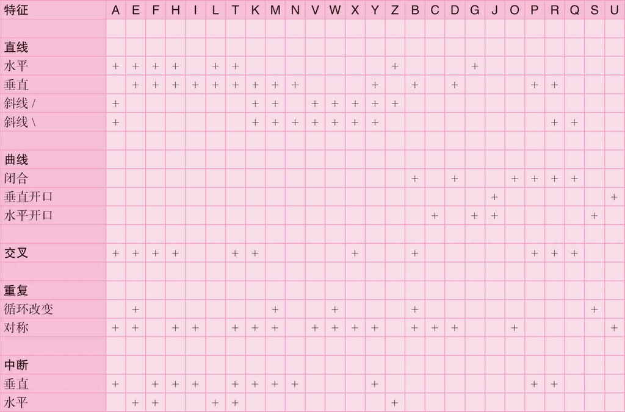

大量行为证据表明，特征是模式识别的组成部分。例如，有证据表明，如果一些字母有许多共同的特征，例如C 和G ，那么人们很容易将它们混淆（Kinney，Marsetta，& Showman，1966）。当这些字母呈现时间非常短时，人们通常会将一个刺激误判为另一个刺激。例如，在金尼（Kinney）等人的实验中，当向被试呈现字母G 时，他们出现了29个错。在这些错误中，有21个是将G 误判成C ，6个是将其误判成O ，1个是误判成B ，1个是误判成9。此外，没有其他错误出现。很显然被试选择具有相似的特征组合的项目作为他们的答案。如果采用了特征分析模型，那么这种反应模式正是我们所期望的。如果被试在短暂呈现的刺激中只能抽取出一部分特征，他们将无法在共有这些特征的刺激之间作出判断。

### 启示

#### 区分人类与BOT

[figure not shown]

图2.17 人类可以识别出CAPTCHAs的例子，但是基于模板的计算机程序则很难识别出。由Luis von Ahn提供。

人类视知觉的特性已经被用于开发CAPTCHAs（von Ahn，Blum，& Langford，2002）。CAPTCHA是“Completely Automated Public Turing Test to Tell Computers and Humans Apart” <sup>(3)</sup> 的简称。开发CAPTCHA的动机源于提供免费电子邮箱的YAHOO所遇到的现实问题。该问题是自动的BOTs <sup>(4)</sup> 会登录系统并利用它们发送垃圾邮件（SPAM）。为了检验是否是真人在操作，系统可以呈现如图2.17所示的图形 <sup>(5)</sup> 。虽然基于模板的方法可能无法识别这样的图形，但是不能说计算机肯定做不到。一些计算机专家将这种图形当成一种智力挑战，一场“军备竞赛”正拉开帷幕：更精巧的识别程序正在显露头角，更具挑战性的CAPTCHAs也正在开发。然而，所有成功的识别方法都与模板匹配无关，而是试图提取这些图形的界定特征（例如，Mori & Malik，2003）。你可以浏览CAPTCHA的网站（http://recaptcha.net/captcha.html）并对CAPTCHA的研究作出贡献。

另一类为特征分析模型提供证据的实验是静止图像实验。眼球会有非常轻微的震颤，被称为心理性眼球震颤，它以每秒30～70次的频率出现。另外，眼睛凝视的方向会缓慢地在物体上漂移。因此，人所注视物体的视网膜图像并不十分稳定，它们的位置会随着时间的推移而略有改变。有证据表明，视网膜的这一运动对知觉极为重要。当使用技术手段使得视网膜图像在有眼动的情况下仍保持在视网膜上完全相同的位置时，该物体的一些组成部分就开始消失。这似乎是因为如果一直使用完全相同的视网膜和神经通路，它们便会疲劳并停止反应。

这一现象最有趣的地方是静止物体消失的方式。它并非简单地逐渐消失或突然完全消失，而是随着时间的推移其不同部分逐渐脱落。图2.18显示了普里查德（Pritchard，1961）在一次实验中采用的一个刺激的命运。最左边为所呈现的图像，其他四个为被试报告的不同的图像。有两点很重要，首先，丢失的似乎是整体特征，例如一条垂直线。这一发现表明特征是知觉的重要单元。第二，剩余的刺激通常为完整的字母或数字图形。这一结果表明这些特征联合在一起以确定所识别的图形。因此，尽管我们的知觉系统可以提取特征，但是，我们所知觉的事物是由这些特征组成的模式。隐含在模式识别中的特征提取和特征组合过程是不能被意识到的，我们所意识到的是模式。

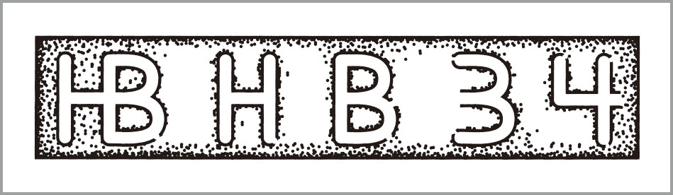

图2.18 静止在眼中的图像的解体。最左边的是原始图像。靠右的其他部分是静止图像开始消失时被试报告的各种图形。 （资料来源：Pritchard，1961．Reprinted by permission of the publisher．©1961 by Scientific American .）

◎特征分析首先识别构成模式的各个特征，然后是它们的组合。

### 物体识别

虽然特征分析能很好地描述我们如何识别诸如字母A 那样的简单物体，但是，人们可能想知道它如何解释我们对复杂物体的识别，这些物体或许是依据少量特征所无法描述的。有证据表明，相同的过程可能出现在识别熟悉物体的时候，例如马或杯子。基本观点是，熟悉的物体可以看成由简单部件组成的已知构形。图2.19所示的是马尔（Marr，1982）关于如何将熟悉物体看成简单的管状部件的构形的设想。例如，鸵鸟有一个水平方向的躯干，躯干上有两条长腿和一个长脖子。

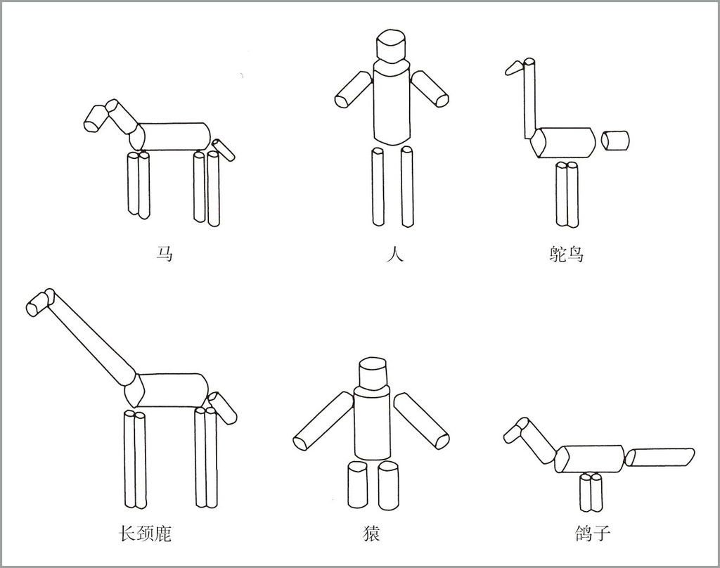

图2.19 将一些熟悉的物体分割成基本的圆柱形。熟悉的物体可以被识别成简单部件组成的构形。 （资料来源：Marr & Nishihara，1978．Adapted by permission of the publisher．©1978 by the Royal Society of London）

比德曼（Biederman，1987）提出了基于部件的识别理论 （recognition-by-components theory）。它认为我们识别由简单部件构成的物体时有三个阶段：

1. 将物体分割成一组基本子物体。这一过程反映了本章前面讨论过的早期视觉加工的输出。
2. 一旦物体被分割成基本子物体，人们就可对每个子物体进行分类。比德曼指出有36个子物体的基本类别，他称之为几何子 （Geon，geometric ion的缩写）。图2.20给出了一些例子。我们可以认为圆柱形是圆沿与圆心垂直的直线（轴）移动而生成的。我们可以通过改变其中的某些属性使产生基本圆柱形的过程生成其他形状的物体。我们可以改变我们所移动物体的形状。如果是矩形而不是圆形沿其轴线移动，那么我们将得到一个长方体而不是圆柱体。我们可以使轴弯曲而得到弯曲的物体。我们可以在移动物体时改变其大小而得到像棱锥或酒杯那样的物体。比德曼认为，采用这种方式生成的36个几何子可以看作构成物体的字母表，就像用来构造词汇的字母表中的字母一样。识别一个几何子包括识别界定它的特征，这些特征描述了生成它的元素，例如移动物体的形状及其移动所沿的轴。因此，识别一个几何子就像识别一个字母。
3. 在识别出了物体的组成部分及它们的构造后，人们就把该物体识别为由这些部分所组成的模式。因此，识别一个物体与识别一个单词一样。

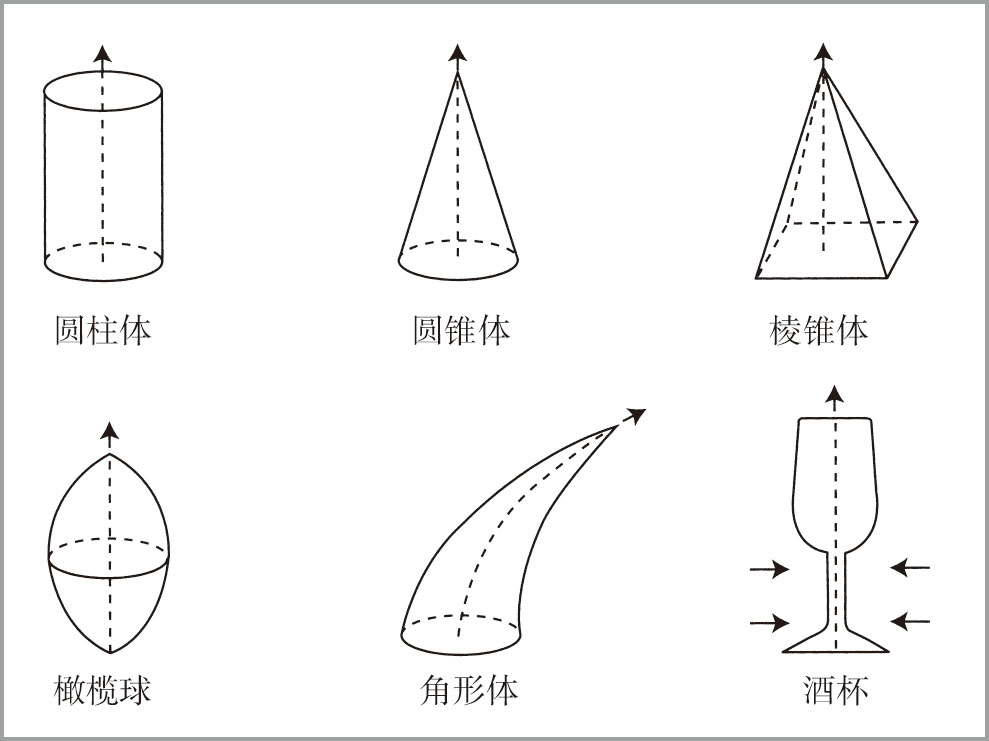

图2.20 比德曼（Biederman，1982）提出的几何子或子物体的基本类别。在每个物体中，虚线表示物体的中心轴。物体可以描绘成由截面图形沿轴线运动生成。圆柱体：由圆沿直线轴移动生成。圆锥体：由圆沿直线轴移动同时收缩生成。棱锥体：矩形沿直线轴移动同时收缩生成。橄榄球：由圆沿直线轴移动同时先扩大再收缩而生成。角形体：圆沿弯曲轴移动同时收缩而生成。酒杯：圆先收缩再扩大构成箭头所指的凹形部分的许多点而生成。 （资料来源：Biederman，Beiring，Ju & Blickle，1985．Reprinted by permission of the authors.）

正如在字母识别时的情况那样，物体识别所基于的几何子会发生一些小的变化，但是这些变化对识别不是至关重要的。例如，人们只需确认边缘是直的还是弯的（例如区分圆柱体和长方体），或边缘是否是平行的（例如区分圆锥体和圆柱体）。人们并不需要精确地指出某个边缘的弯曲程度如何。只有边缘是定义几何子所需要的，颜色、纹理以及小的细节都不重要。如果这一假设是正确的，那么对一个能看出基本几何子的复杂物体的线条示意画的识别就能像对具有该物体细节的彩色照片的识别那样迅速。比德曼和鞠（Biederman & Ju，1988）用实验证实了这个假设：像电话这样的物体的线条示意画提供了能够迅速而准确识别它的所有信息。

这个理论的关键假设是，物体识别是以对其部件的识别为中介而实现的。比德曼、贝宁、鞠和布里克利（Biederman，Beiring，Ju & Blickli，1985）采用如图2.21所示的物体对该假设进行了检验。一些物体的某些部件被整个删除；而另一些物体则具有所有部件，只是删除这些部件的某些片段。他们以不同的速度向被试呈现这两种经过删除的图画，并要求他们识别这些物体。测试结果如图2.22所示。呈现时间非常短暂（65～100毫秒），被试对删除完整部件的图的识别要比对删除局部轮廓的图的识别更为准确；当呈现时间更长时，例如呈现200毫秒，则出现了相反的情况。比德曼等人解释道，在非常短的时间内，被试不能识别出删除局部轮廓的部件，因此难以识别物体。然而，当呈现时间为200毫秒时，被试在任何一种条件下都能识别所有的成分。由于删除局部轮廓的情况下有更多部件，因此它们拥有更多识别物体的信息。

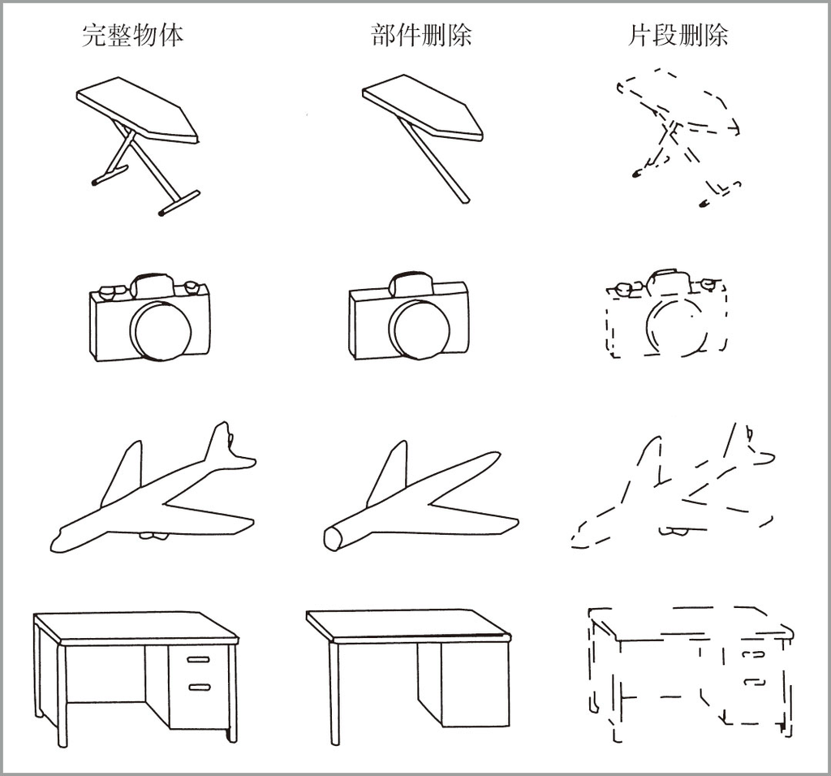

图2.21 检验物体识别是以对部件的识别为中介而实现的理论。比德曼等人（1985）的实验所用刺激的范例。相同比例的部分从完整物体的图片中被删除。一种条件是某些部件被整个删除；另一种条件是删除各部件的某些中间部分的轮廓。图2.22显示了实验结果。 （资料来源：Biederman，1987．Adapted by permission of the publisher．©1987 by the American Psychological Association.）

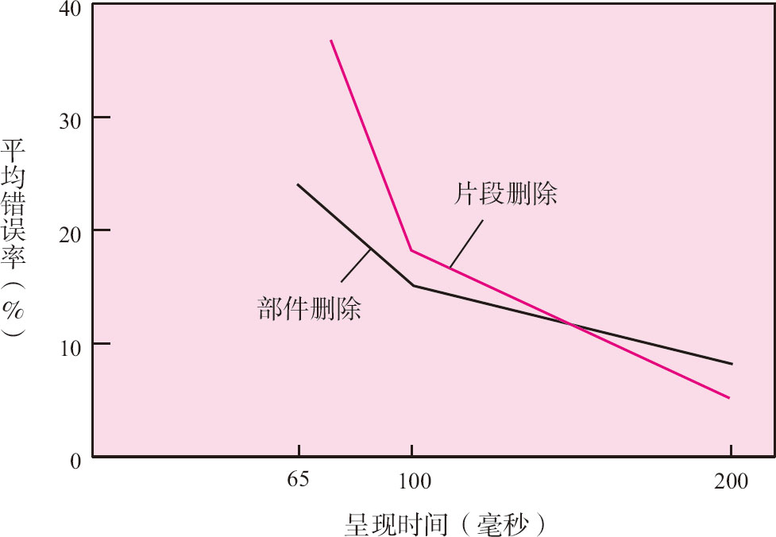

图2.22 为确定物体识别是否以识别该物体的部件为中介，比德曼等人（1985）所做测试的结果。把物体命名错误的平均比例作为轮廓删除类型（删除局部轮廓或删除完整部件）和呈现时间的函数进行绘图。 （资料来源：Biederman，1987．Adapted by permission of the publisher．©1987 by the American Psychological Association.）

◎像马和杯子之类的物体被识别成一组简单子物体的构形。

### 脸的识别

脸是视觉刺激中最重要的类别之一，有理论认为我们有专门识别脸的机制。在猴子的颞叶中找到了对其他猴子的脸优先反应的特定细胞（Baylis，Rolls，& Leonard，1985；Rolls，1992）。如果人的颞叶受到损伤，可能会造成被称为人脸失认症 （prosopagnosia）的缺陷，他们对脸的识别存在选择性困难。采用fMRI技术的脑成像研究发现，当脸出现在视野中时，颞叶的一个叫做梭状回 （fusiform gyrus）的特定区域会做出反应（例如Ishai Ungerleider，Martin，Mailsog，& Haxby，1997；Kanwisher，McDermott & Chun，1997；McCarthy，Puce，Gore，& Allison，1997）。

脸加工专门化的证据之一出自对倒置的脸识别的研究。在一项原创性的研究中，殷（Yin，1969）发现，人们对垂直方向呈现的脸的识别要比对以同样方向呈现的其他类别物体的识别（例如房子）要好得多。然而，当脸倒置呈现时，对其的识别能力急剧下降，但对其他物体的识别则不会出现这种情况。因此，这似乎表明我们有特别的识别脸的能力。研究还发现，当脸倒置呈现时，梭状回的fMRI的反应减弱（Haxby et al，1999；Kanwisher，Tong，& Nakayama，1998）。另外，当脸的某个部分（例如鼻子）出现在脸上时，识别起来会更容易；但是，在识别一幢房屋的组成部分（例如窗户）时则没有同样的情境依赖（Tanaka & Farah，1993）。所有的这些证据导致一些研究者认为我们特别善于识别整体的脸，有时候这一特殊的能力被论证是通过进化获得的。

另外的研究则不支持脸识别特异化的结论，而是提供了梭状回专门作出精细辨别的证据。我们对脸极为熟悉，因此在对脸进行识别的过程中我们善于作出这种细致的判断。但是，对于那些我们已经非常了解的其他刺激，也可以看到类似的效应。例如，高蒂尔、斯卡德拉斯基、戈尔和安德森（Gauthier，Skudlarski，Gore，& Anderson，2000）发现，鸟类专家或汽车专家对鸟类或汽车进行判断时，他们的梭状回也会表现出高度激活。在另一项研究中，经过大量的练习之后，人们识别一组名为greeble的不熟悉物体（图2.23）时，梭状回也会表现出激活。

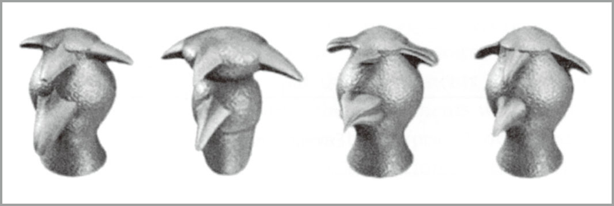

图2.23 “Greeble专家”在识别这些物体时会使用脸识别区。 （资料来源：Gauthier，Tarr，Anderson，Skudiarski，& Gore，1999．Reprinted by permission of the publisher．©1999 by Nature Neuroscience .）

◎识别人脸时，位于颞叶的梭状回变得活跃起来。

## 言语识别

到目前为止，我们只讨论了视觉模式识别。对该结论普遍性的一个有趣检验是，它们是否能推广至言语识别。虽然我们不打算讨论早期言语加工的细节，但是类似的问题值得关注。言语识别的一个主要问题是待识别对象的分割。言语不能像打印的文本那样被分成离散的单元。尽管在言语中词与词之间似乎存在界限分明的停顿，但是这些停顿往往是一种错觉。如果我们分析言语的真实物理信号，常常会发现在词的边界处声能并未衰减。事实上，出现在单词内的声能间隔与出现在单词间的非常相似。在听别人说一种我们不熟悉的外语时，言语的这种特性会特别明显。言语似乎是连续的声音流，中间没有明显的单词界限。正是由于我们对自己母语的熟悉，才导致言语中有词间间隔存在的错觉。

在一个单词内甚至存在着更大的分割问题。这些单词内的问题涉及到对音素 （phonemes）的识别。音素是语音的基本单元，我们借助音素来识别单词 <sup>(6)</sup> 。音素被定义为导致口语信息差别的言语的最小单元。为了更好地说明问题，请考虑bat （蝙蝠）一词。这个词由三个音素组成：/b/，/a/和/t/。如果用音素/p/取代音素/b/，我们就得到pat （轻拍）；如果音素/i/取代音素/a/，我们就得到bit （少量）；如果用音素/n/取代音素/t/，我们就得到ban （禁止）。很显然，在字母与音素之间并非总存在着一一对应的关系。例如，单词one 由音素/w/，/e/和/n/构成；单词school由音素/s/，/k/，/u/和/l/构成；单词knight 由音素/n/，/i/和/t/构成。正是字母与读音之间缺乏严格的对应关系才使得英语拼写如此困难。

当需要识别构成所说单词的音素时，分割问题便出现了。困难在于言语是连续的，音素无法像印刷在纸页上的字母那样分开。在这个层面上的分割就像识别手写（不是印刷的）文字那样，一个字母连上另一个字母。另外，就像手写体的字迹不同那样，不同的说话者对同一音素的发音也各不相同。例如，当一个人试图听懂一位带有浓重口音的人所说的不熟悉的方言时，会发现说话人之间的差异极为明显，如美国人试图听懂澳大利亚人说话。然而，对言语信号的分析发现，即使操着相同口音的说话者也存在着相当大的差异。例如，妇女和儿童的声音通常要比男士的音调高很多。

言语感知中更进一步的困难在于一种被称为连音的现象（Liberman，1970）。当声道发出一个音时，例如：发bag中的/b/音，它要向发/a/音所需的口形移动。发/a/音时，它要向发/g/音的口形移动。实际上，各个音素是重叠的。这就为音素分割增添了新困难，而且还意味着一个音素的实际发音由其前后的其他音素决定。

言语知觉所提出的信息加工要求在很多方面都高于听知觉。研究者们报告了许多由于左颞叶损伤而丧失了听语言能力的患者（参阅Goldstein，1974的综述）。他们察觉和识别其他声音的能力以及说话的能力依然完好。因此，他们损伤的只是言语知觉。如果所听的言语说得非常慢，患者偶尔也会听懂（参见Okada，Hanada，Hattori，& Shoyama，1963），这表明其中某些问题可能出在对言语流的分割上。

◎言语识别包括将音素从连续的言语流中分割出来。

### 言语的特征分析

就像在视觉识别中那样，特征分析和特征组合的加工似乎也存在于言语知觉中。如同单个字母那样，单个音素可以分解成由许多特征组成。这些特征涉及音素是如何产生的。音素的特征包括辅音特征、浊音音质和发音部位（Chomsky & Halle，1968）。辅音特征 （consonantal feature）是一个音素的辅音特质（与元音特质相反）。浊音音质 （voicing）是由声带振动发出的音素声音。例如，比较你说单词sip 和zip 的方式。sip 中的/s/是清音，而zip 中的/z/是浊音。在发这些声音时将手指放在喉部，你就会发现它们的不同之处。喉部会在发浊辅音时振动。

发音部位 （place of articulation）是指在发音时声道处于闭合或者紧缩状态的部位（在发大多数辅音时，声道在某点上闭合）。例如，/p/、/m/和/w/被称之为双唇音，因为在发这些音时双唇是闭合的。音素/f/和/v/被称之为唇齿音，因为要用上门齿压下嘴唇。/th/表征两个不同的音素，一个在thy 中，另一个在词thigh 中。二者皆为齿音，因为舌头需触压牙齿。音素/t/、/d/、/s/、/z/、/n/、/l/和/r/都是齿龈音，因为发音时舌头需触压在正好位于上门齿后牙龈的牙槽嵴处。音素/sh/、/ch/、/j/和/y/都是腭音，因为发音时舌头需触压在正好位于牙槽嵴后的口腔的顶部。音素/k/和/g/都是软腭音，因为发音时舌头需触压在接近口腔后顶部的软腭处。

请思考一下音素/p/、/b/、/t/和/d/，它们都具有辅音特征。然而可以根据浊音音质和发音部位对这四个辅音进行区分。表2.2中按照这两个特征对这四个音素作了分类。

表2.2 根据浊音音质和发音部位对/b/、/d/、/p/和/t/这四个音素所作的分类。

| 发音部位 | 浊音音质 |  |
| --- | --- | --- |
|  | 浊音 | 清音 |
| 双唇音 | /b/ | /p/ |
| 齿龈音 | /d/ | /t/ |

大量的证据支持这些特征在言语知觉中的作用。例如，米勒和奈斯利（Miller & Nicely，1955）让被试在噪声环境中尝试识别诸如/b/、/d/、/p/和/t/等音素 <sup>(7)</sup> 。在噪声环境下被试会把声音混淆，将实际呈现的一种声音听成是另一种声音。实验者感兴趣的是，当呈现一种声音时，被试会将它与哪些声音相混淆。看起来，最有可能混淆的是仅有一个特征不同的辅音，这一预测得到了证实。例如，当呈现音素/p/时，被试把它听成是音素/t/的次数超过听成音素/d/的次数。音素/t/与音素/p/仅在发音部位上有所不同，而/p/与音素/d/的发音部位和浊音音质都不相同。与此类似，当呈现音素/b/时，被试把它误听成/p/的次数超过误听成/t/的次数。

这个实验比金尼等人（Kinney et al.，1966）的字母识别研究更早地证明了相同的逻辑。当被试只能辨别出一个模式的部分特征时（在这里，模式是音素），被试在具有这些共同特征的音素之间出现了混淆反应。

◎音素识别依据的是音素产生过程中的特征，例如发音部位和浊音音质。

## 类别性知觉

音素特征指的是音素发音时的性质，听觉刺激的哪些性质对这些发音特征进行编码呢？在浊音音质方面，该问题已经得到了非常好的研究。在发/b/和/p/这样的辅音时，发生了两件事：闭合的双唇张开，空气释放和声带开始振动（voicing） <sup>(8)</sup> 。在发浊辅音/b/时，空气释放和声带振动几乎是同时发生的。在发清辅音/p/的情况下，空气释放是在声带振动开始前60毫秒时发生的。当我们知觉一个辅音是清辅音还是浊辅音时，我们觉察到的是在空气释放和声音振动之间是否存在60毫秒的间隔。这段时间间隔被称为声带振动开始时间。浊辅音/b/和清辅音/p/之间的差别见图2.24。类似的差别也存在于其他的浊辅音-清辅音对中，例如/d/和/t/。此时，控制音素知觉的因素又成了空气释放和声带振动之间的时间延迟。

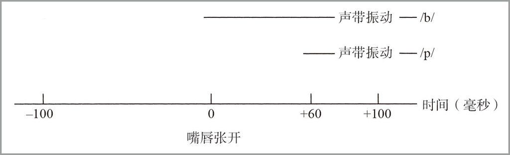

图2.24 浊辅音/b/和清辅音/p/之间的差别在于，在发/p/音时存在嘴唇张开和声带开始振动之间的时间延迟。 （资料来源：H．H．Clark & E．E．Clark，1977．Reprinted by permission of the publisher．©1977 by Harcourt Brace Jovanovich.）

利斯克和艾布拉姆森（Lisker & Abramson，1970）用人工（由计算机产生的）刺激做了一系列实验。在这些实验中，空气释放和声带振动之间的时间延迟在-150毫秒（声带振动在空气释放前150毫秒）至150毫秒（声带振动在空气释放后150毫秒）之间变化。任务是分辨出哪些声音是/b/以及哪些声音是/p/。图2.25是识别为/b/和识别为/p/的百分比。在连续体的大部分时间里，被试在他们所听到的内容上100％一致，但是，在声带振动起始时间约25毫秒时出现了从/b/到/p/的突变。在声带振动起始时间为10毫秒处，被试几乎一致认为声音是/b/；而在40毫秒时，他们几乎一致认为声音是/p/。由于浊辅音与清辅音之间存在着这一突变的分界线，因此，对这一特征的知觉具有类别性。类别性知觉 （categorical perception）是指对属于不同类别的刺激的知觉，它不能觉察类别内刺激的渐变。

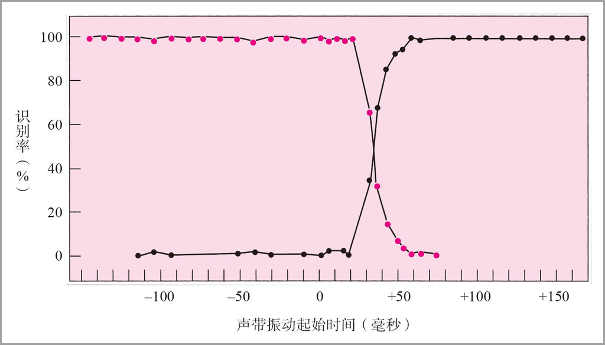

图2.25 识别为/b/与/p/的百分比是声带振动起始时间的函数。识别函数的突变出现在大约＋25毫秒处。 （资料来源：Lisker & Abramson，1970．Reprinted by permission of the publisher．©1970 by Academia.）

支持言语的类别性识别的另一证据来自辨别研究（综述见Studdert-Kennedy，1976）。人们非常不善于辨别具有不同声带振动起始时间的一对/b/，或者具有不同声带振动起始时间的一对/p/。然而却善于辨别在声带振动起始时间上具有相同差异，但其中一个是/b/和一个是/p/的音素对。看来，人们只能够识别一个声音的音素类别，却不能在音素类别内进行辨别。因此，只有当两个声音出现在音素边界的两侧时，人们才能够分辨它们。

关于类别性知觉究竟意味着什么，至少存在着两种观点，它们的区别在于对知觉本质的强调不同。较弱的观点认为，我们体验的是来自不同类别的刺激。看起来，对于音素知觉是这种意义下的类别性知觉似乎争论不大。较强的观点认为，我们无法辨别类别内的刺激。马萨罗（Massaro，1992）针对这一观点提出了异议，他认为存在着些许类别内的分辨能力。他进一步指出，类别内辨别能力低下可能反映了被试的一种偏好：即使存在着可以辨别的差异，他们仍倾向于说类别内的刺激是相同的。

为言语识别中使用浊音音质特征提供了支持证据的另一条研究路线是自适应范式。埃马斯和科比特（Eimas & Crotbit，1973）让被试听重复呈现的声音da ，这个声音包含一个浊辅音/d/。研究者推断，浊辅音的持续重复可能会造成检测浊音音质特征的觉察器的疲劳或适应。然后，他们向被试呈现一系列人工声音，这些声音处于某个声音的连续体内，例如ba 与pa 之间的范围（就像前面介绍的利斯克和艾布拉姆森的研究那样，1970）。他们要求被试指出，这些人工刺激听起来更像ba 还是更像pa 。（请记住，在ba 与pa 之间唯一的差别在于浊音音质。）埃马斯和科比特发现，在通常情况下被报告成浊音ba 的一些刺激，现在被报告成清音pa 。因此，重复呈现声音da 造成了浊音音质特征觉察器的疲劳，提高了觉察ba 中浊音音质的阈值，从而使先前的许多ba 刺激听起来像pa 。

虽然言语知觉在某种意义上是类别性的已经是一种共识，但是关于这种现象背后的机制仍存在很大争论。一些研究者（例如，Liberman & Mattingly，1985）认为这反映了能够使人感知到声音是如何产生的特殊的言语知觉机制（第11章和第12章将深入讨论该主题）。例如，清辅音和浊辅音产生时的类别性区别——发音时声带是否振动。该事实被用来说明我们是通过感知辅音如何产生来感知浊音音质的。但是，有证据表明类别知觉并不专属于人类的语言加工，而是反映了某些声音如何被感知的一般特性。例如，皮索尼（Pisoni，1977）制造出了一些非语言纯音，它们具有与声带振动相似的声学特征——一个低频音与一个高频音同时产生，或者期间有60ms的时间延迟。被试显示了与图2.25中所示的言语信号边界相同的边界。在另一项研究中，库尔（Kuhl，1987）训练南美栗鼠区分浊辅音“da”和清辅音“ta”。即便这些小动物没有人的声道，它们仍然像人一样在这两种刺激间产生了清晰的边界。因此，类别性知觉似乎既不依赖于语音信号（Pisoni，1977），也不依赖于知觉者是否具有人类发声系统（Kuhl，1987）。迪尔等人（Diehl，Lotto，& Holt，2004）认为我们所使用的音素是经过选择的，所以它们在言语听觉知觉中存在着类别边界。因此，更有可能的是，知觉系统决定了我们的言语行为，而不是言语行为决定了我们的知觉。

◎在连续维度上不同的语音听起来属于不同的类别。

## 情境与模式识别

迄今为止，在我们对模式识别的讨论中，似乎模式识别系统唯一可利用的信息是待识别的物理刺激中的信息。然而，情况并非如此。物体总是出现在情境中的，而我们可以利用情境来识别物体。请看图2.26中的例子。我们会将这些符号看成是THE 和CAT ，尽管H 和A 用的是完全相同的符号。单词提供的整体情境迫使人们获得相应的理解。当情境或世界的一般性知识指导知觉时，我们将这种加工称为自上而下加工 （top-down processing），因为高层次的一般性知识影响着低层次的知觉单元的解释。知觉中的一个普遍问题是，这种自上而下加工与不考虑整体情境而直接对信息本身进行的自下而上加工 （bottom-up processing）是如何结合的。

[figure not shown]

图2.26 情境作用的一个例子。由于所处情境的不同，相同的刺激被知觉成H或A。 （资料来源：Selfridge，1955．Reprinted by permission of the publisher．©1955 by the Institute of Electrical and Electronics Engineers.）

自上而下效应的一条重要研究路线是由赖歇尔（Reicher，1969）和惠勒（Wheeler，1970）开创的一系列字母识别实验。快速呈现给被试一个字母（如D ）或者一个单词（如WORD ），然后立即向被试提供两个选择，要求他们报告刚才看到的是两个选择之中的哪一个。（最初的呈现时间足够短暂，以至被试在这项识别任务中大量出错。）如果向他们呈现的是字母D ，那么可能会向他们呈现D 和K 以供选择。如果向他们呈现的是单词WORD ，那么可能向他们呈现单词WORD 和单词WORK 以供选择。请注意，这两个选择答案都只是字母D 或字母K 的差别。被试识别单词时的正确率比识别单独字母高10％。因此，被试在单词情境下比在只有字母的情况下能更好地区分字母D 和K 。尽管从某种意义上说，他们在单词情境下要对四倍数量的字母进行加工。这种现象就是单词优势效应 （word superiority effect）。

图2.27显示了鲁姆哈特和赛普尔（Rumelhart & Siple，1974）以及汤普森和马萨罗（Thompson & Massaro，1973）对为什么人们在单词情境下能更准确地识别字母提出的一种解释。图中所示的是不完整知觉的产物：无法知觉字母的某个部分——组（a）中仅有最后一个字母被遮挡，而组（b）中多个字母被遮挡。如果只给被试看最后一个字母，那么被试可能无法说出这个字母是K还是R。因此，刺激信息不足，无法认出字母。另一方面，情境本身也没有提供足够的信息——虽然组（a）中前三个字母清楚地显示出是WOR，但是以WOR开头的四个字母的单词有很多：WORD，WORE，WORK，WORM，WORN，WORT。然而，如果被试将来自刺激的信息和来自情境的信息结合起来，那么整个单词必定是WORK，也就意味着K是最后一个字母。并不是被试在WOR的情境下对K看得更清楚，而是他们更能够推断出K就是第四个字母。但是被试并没有意识到这些推断，所以可以说他们在知觉过程中做出了无意识推断。特别需要注意的是，在这个例子中被试并没有有意识地通达特定特征，比如目标字母右下角有条斜线。否则，当只给出单个字母时，他们能够正确地选择D或K。被试只是有意识地通达了知觉系统所感知到的整个单词或整个字母。注意，这种分析并不仅限于情境字母无歧义的情况。在组（b）中，第二个字母可能是O或U，第三个字母可能是B、P或R。但是，WORK仍然是唯一可能的单词。

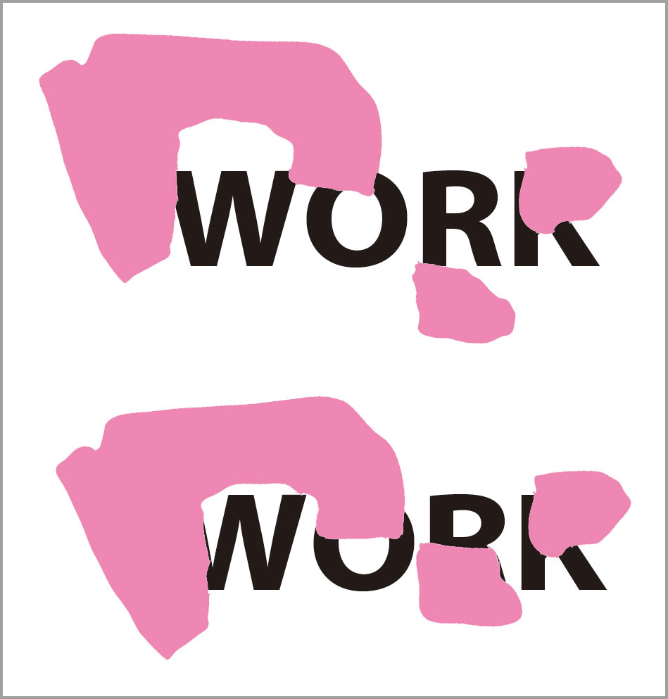

图2.27 在一个单词知觉实验中可能提取一组假设特征：（a）只有最后一个字母被遮挡；（b）多个字母被遮挡。

这个例子表明，许多像单词这样的复杂刺激中存在冗余信息。这些刺激包含了远远多于将一个刺激与另一个刺激区分开所需的特征。因此，当只有部分特征可识别时，知觉也能够成功地进行下去，其余特征可以由情境补充。在语言中，这种冗余信息存在于除特征层次外的许多其他层次上。例如，在字母层次存在着冗余信息。我们无需知觉一长串单词中的每一个字母就能将它们读出来。To xllxstxatx，I cxn rxplxce xvexy txirx lextex of x sextexce xitx an x，anx yox stxll xan xanxge xo rxad xt–ix wixh sxme xifxicxltx. <sup>(9)</sup>

◎在字母识别中，单词情境可以用来补充特征信息。

### 综合情境与特征信息的马萨罗FLMP模型

我们已经回顾了种种知觉情况下模式识别中的情境效应，但是如何在概念上解释这些效应依然是个问题。马萨罗认为，刺激和情境提供了关于刺激本体的两个独立的信息源，二者组合在一起提供有关刺激可能是什么的最佳猜测。图2.28显示了他在区分字母c 与字母e 的识别测试中所用的材料。图中4个象限代表了情境所能提供的证据的4种可能情况：只有用字母e 才可以构成的单词（左上）；只有用字母c 才可以构成的单词（左下）；c 和e 两者都可以构成的单词（右上）；两个字母无论用哪个都构不成单词的字符串（右下） <sup>(10)</sup> 。在一个象限内自上而下，一个模棱两可的字母图形从最像c 逐渐变为最像e 。向被试短暂地呈现这些刺激并要求他们识别该字母是c 还是e <sup>(11)</sup> 。图2.29表明识别结果是刺激与情境信息的函数。当字母图形自身提供了更多的识别为e 的证据时，被试识别该字母为e 的概率增加。同样，当情境提供更多的识别为e 的证据时，识别为e 的概率也增加了。

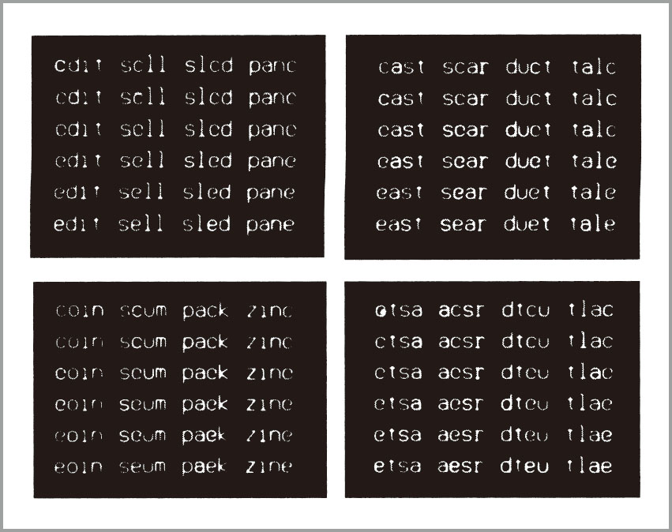

图2.28 马萨罗（Massaro，1979）研究被试如何组合来自字母的刺激信息和来自字母周围的情境信息时所采用的情境线索。 （资料来源：Massaro，1979．Reprinted by permission of the publisher．©1979 by the American Psychological Association.）

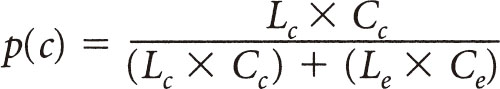

图2.29中的曲线显示了根据他的理论所作的预测。一般说来，马萨罗的理论［即知觉的模糊逻辑模型 （fuzzy logical model of perception，FLMP）］很好地解释了模式识别中情境和刺激信息的组合。

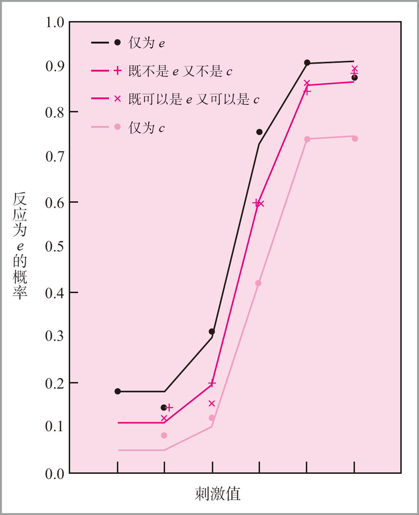

图2.29 反应为e 的概率是测试字母的刺激值和字形情境的函数。曲线反映了马萨罗的FLMP模型的预测。最左侧的曲线表示情境提供的证据是字母仅能为e 的情况。中间的曲线表示在情境提供的证据支持字母既可以是e 又可以是c 或者既不可以是e 又不可以是c 这两种情况下做出的预测相同。最右侧的曲线为情境提供的证据是字母仅能为c 的情况。 ［译者注：图2.29中的点是实验数据（反应为e的概率），因为被试必须从c和e中两者择一，反应为c的概率＝1-反应为e的概率（将图中数据沿p＝0.5水平线旋转180˚即得）。］（资料来源：Massaro，1979．Reprinted by permission of the publisher．© 1979 by the American Psychological Association.）

◎知觉的马萨罗FLMP模型指出，情境信息与刺激信息各自独立地提供信息，共同决定知觉到的模式。

### 情境与识别的其他例子

我们已细致分析了单词识别，如马萨罗阐明了情境如何影响知觉。然而，情境的影响是普遍存在的。例如，同样有大量证据表明情境在言语知觉中的作用。一个很好的例子是最初由沃伦（Warren，1970）在实验中所发现的音素复位效应 （phoneme-restoration effect）。他让被试听句子“The state governors met with their respective legislatures convening in the capital city” <sup>(12)</sup> ，其中位于legislatures 一词中间的字母s 被120毫秒的纯音所取代。结果20个被试中只有1名报告听到了纯音，但这名被试无法正确地说出纯音的位置。

对这项最初研究的一个有趣的拓展是由沃伦和沃伦（Warren & Warren，1970）所作的一个实验。他们向被试呈现如下所示的句子：

It was found that the *eel was on the axle．

It was found that the *eel was on the shoe．

It was found that the *eel was on the orange．

It was found that the *eel was on the table．

在每个句子中，*表示用非言语声音代替了一个音素。对于上述4个句子，被试根据情境报告听到了wheel ，heel ，peel 和meal <sup>(13)</sup> 。上述这些句子的一个值得注意的重要特点是，每句从开始到关键单词都是一样的。对这些关键单词的识别由出现在它后面的单词所决定。因此，对单词的识别通常不是即时发生的，它可能依赖于对后续单词的知觉。

对复杂视觉景象的知觉来说，情境似乎也很重要。比德曼、格拉斯和斯泰西（Biederman，Glass，& Stacy，1973）考查了新异景象中的物体知觉。图2.30为他们向被试呈现的两种景象。图2.30a为正常景象，相同的景象在图2.30b中被打乱了。被试观看在屏幕上短暂呈现的其中的一幅景象，然后立即在空白屏幕上出现一个箭头，该箭头所指的位置是之前景象中的一个物体的位置，他们要求被试指出这个物体是什么。在这个例子中，箭头可能指向了消防栓所处的位置。当被试观看连贯画面时，要比观看杂乱画面时能更准确地完成识别任务。因此，就像对文本或言语的加工那样，人们能够使用视觉景象中的情境信息来识别物体。

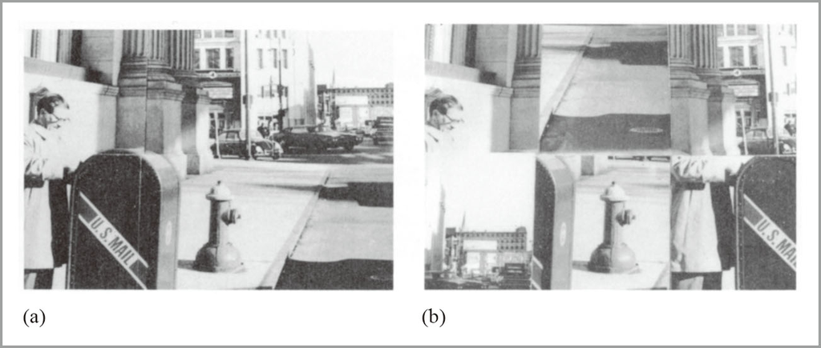

图2.30 比德曼等人（Biederman，Glass，& Stacy，1973）研究复杂视觉景象识别中的情境作用时使用的景象：（a）连贯的景象；（b）杂乱无章的景象。在杂乱无章的景象中更难以识别消防栓。 （资料来源：Biederman，Glass，& Stacy，1973．Reprinted by permission of the publisher．© 1973 by the American Psychological Association.）

最具戏剧性的一个情境影响知觉的例子是变化盲 （change blindness）现象。人们不能在一个典型的复杂景象中追踪所有信息。当视网膜受到干扰（例如眼动或电影中的镜头切换）时，如果景象中的元素发生变化，且它与情境相匹配，那么人们通常不能觉察这种变化。在最早关于变化盲的研究中（McConkie & Currie，1996），当被试发生眼动时，在其所观看的图片中引入一个巨大的变化。例如，画面中汽车的颜色可能变了，而被试通常觉察不到这些变化。图2.31是变化盲的一个生动例子（Simons & Levin，1998）。主试在康奈尔大学校园中拦住过往的行人向他们问路，就在毫不知情的被试正在指路时，几名工人抬着一扇门从主试和被试之间穿过。一名同伙替换了主试。15名被试中只有7名注意到了这种变化。在图2.31所示景象中，被试自认为正在为一名学生指路，只要调换了的主试满足这个解释，被试就不会发现已经换了人。在一个关于人脸变化的觉察能力的实验室研究中，贝克等人（Beck，Rees，Frith，& Lavie，2001）发现，与没有觉察到脸变化相比，被试觉察到脸变化时其梭状回有较强的激活（参见上文有关面部识别的讨论）。

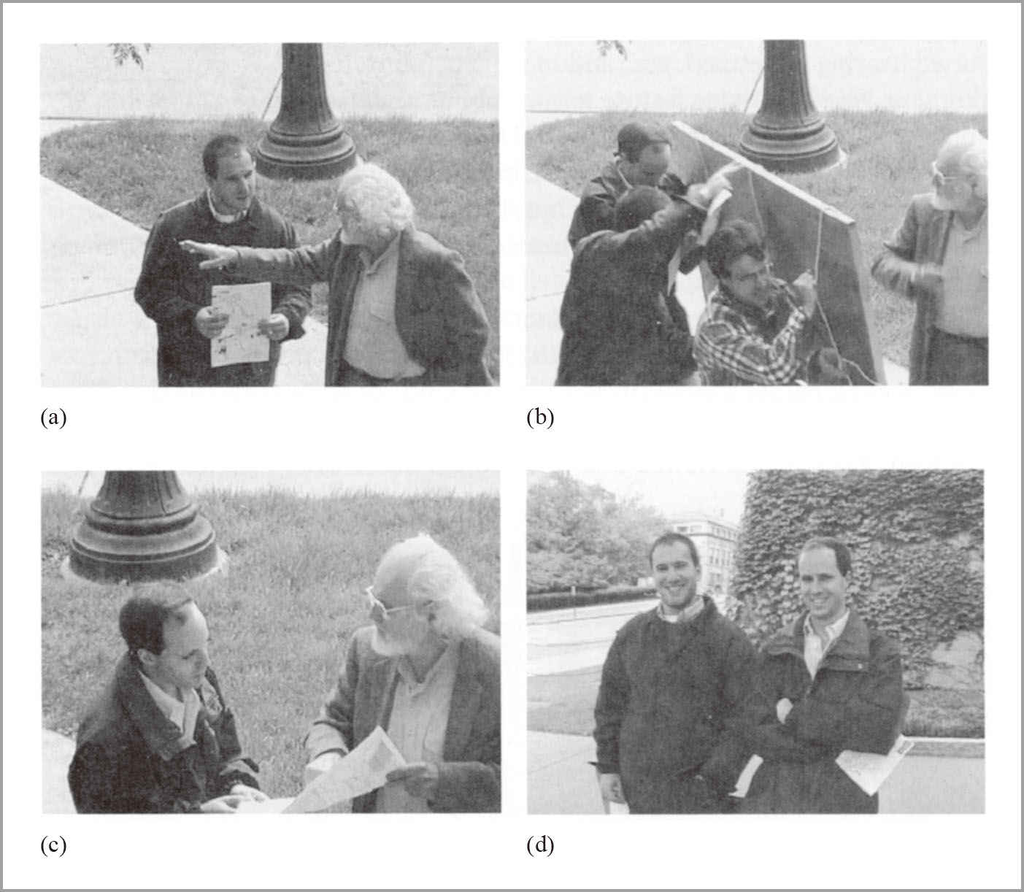

图2.31 变化盲的一个例子。画面来自一段录像，就在工人们抬着一扇门从一名主试和一名毫不知情的被试之间穿过时，主试的同伙替换了他。15名被试中只有7名注意到了这种变化。（a）到（c）表示替换的过程；（d）为两名主试。 （资料来源：Simon & Levin，1998．Reprinted by permission of the publisher．©1998 by Psychonomic Bulletin and Review .）

◎在多种情况下情境信息都会影响知觉加工。

## 结论

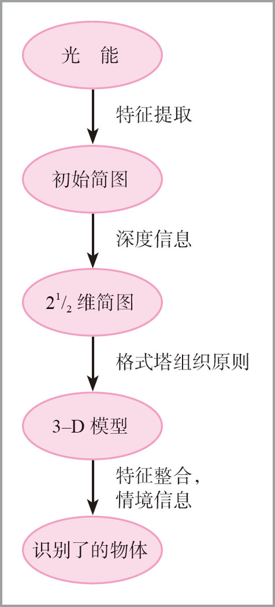

图2.32 我们如何加工来自环境的信息并形成对它们的知觉表征。椭圆框代表了马尔（Marr，1982）模型中不同的信息层次。箭头线旁标注的是从一个信息层转换到下一个信息层的感知过程。

### 思考题

1. 图2.33a所示的是以其发现者奥地利物理学家和哲学家厄恩斯特·马赫（Ernst Mach）的名字命名的视觉错现象——马赫带。每条带里的灰度都相同，但是与深色带相交的边界线的右侧看起来亮一些，与浅色带相交的边界线的左侧看起来暗一些，你能用开闭细胞、边缘觉察器和直条觉察器解释这一现象吗（见图2.7和图2.8）？
2. 使用格式塔原则解释为什么我们会在图2.33b中看到两个三角形。
3. 比得曼的几何子观点认为人们通过识别组成成分中的抽象特征来识别客体（见图2.20），而厄尔曼（Ullman，2006）认为我们通过识别像图2.33c那样的具体片段来识别客体。几何子理论和片段理论的相对优势各是什么？
4. 从图2.29中，我们看到，当呈现刺激“cdit”时，被试有较大可能性会说他们看到的是英语单词“edit”。有人认为这是情境歪曲知觉的例子。你同意说这是一种歪曲吗？

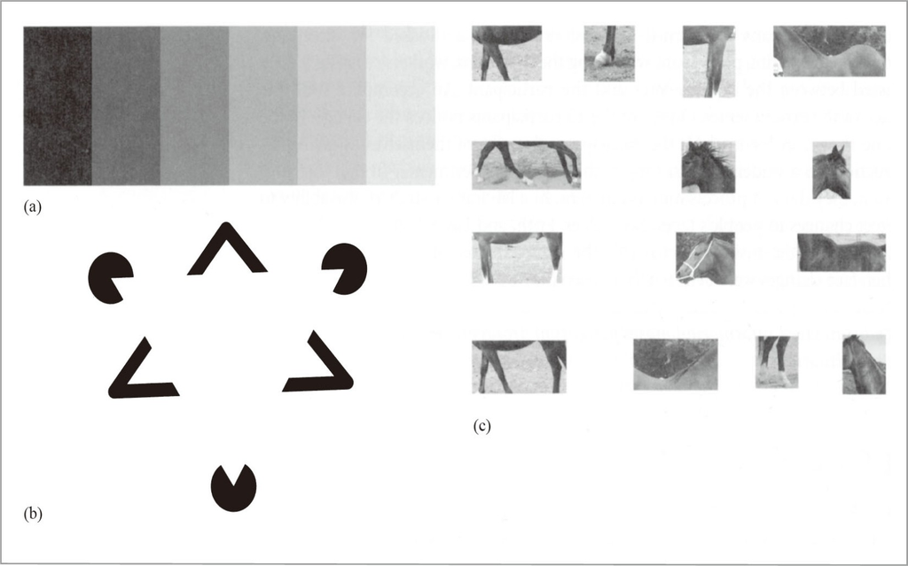

图2.33 思考题中的图。（a）马赫带；（b）格式塔组织原则示例；（c）厄尔曼（Ullman，2006）提出的识别一匹马所需的片段。

### 关键术语

视觉失认症

统觉失认症

联想失认症

中央凹

边缘觉察器

直条觉察器

特征地图

21/2维简图

3-D模型

格式塔组织原则

模板匹配

特征分析

基于部件的识别理论

几何子

人脸失认症

梭状回

音素

辅音特征

浊音音质

发音部位

类别性知觉

自上而下加工

自下而上加工

单词优势效应

知觉的模糊逻辑模型

音素复位效应

变化盲

初始简图

(1) For instance this sentence is hard to read（直译为：例如，这个句子难以阅读）——译者注

(2) 原文为“CAPTCHAS”，应为“CAPTCHA”的复数“CAPTCHAs”。经作者认可修改。——译者注

(3) 直译为‘区分计算机和人类的公共图灵测试’。——译者注

(4) BOT在这里指的是internet bot或Web Robert（网络机器人）。它是一种黑客软件，能通过网络以比人快得多的速度自动（或受控）重复执行简单操作来窃取文件或散布垃圾邮件等。——译者注

(5) 人可以识别并键入其中的字母与数字，然后被允许进入系统。目前采用模板匹配方法的计算机程序识别不了它们，无法键入其中的字母与数字，因而不能进入系统。——译者注

(6) 马萨罗（Massaro，1996）提出了另一种经常提到的说法，认为基本的知觉单元是辅音-元音组合和元音-辅音组合。

(7) 实际上向被试呈现的声音是ba 、da 、pa 和ta 。

(8) 作者在email中说明“I think voicing refers to both the process and the resulting sound”.当“voicing”指“the resulting sound”时，我们译成“浊音音质”；当“voicing”指“the process”时，我们译成“声带振动”。——译者注

(9) 将‘x’处补齐，这句话成为：To illustrate，I can replace every third letter of a sentence with an x，and you still can manage to read it–if with some difficulty.（直译为：作为例证，我可以将一个句子的所有第三个字母替换成x，你仍然能够设法把它读出来，尽管或许有一点困难。）——译者注

(10) （左上），（左下），（右上），（右下）为译者所加。——译者注

(11) 图2.28中每个象限有6行，对应着刺激值从1到6的目标字母图形，刺激值为1对应c，刺激值为6对应e（参见图2.29）。每次测试呈现一个字符串，例如cdit，要求被试判别此时的目标字母图形是c还是e。在图2.28的4个象限中，左上象限里的edit，sell，sled，pane是英语单词，cdit，scll，slcd，panc都不是英语单词；左下象限里的coin，scum，pack和zinc是英语单词，eoin，seum，paek，zine不是英语单词；右上象限里的cast，east，scar，sear，duct，duet，talc和tale均是英语单词，而右下象限中全都不是英语单词。——译者注

(12) 直译为：州长们分别会见了自己的州在首都的立法人员。

(13) 有了这些单词后，上述四个句子译为：人们发现轮子在轴上；人们发现鞋跟在鞋上；人们发现果皮在橙子上；人们发现饭在桌上。

# 第3章 注意与操作

第 2章介绍了人类的视觉系统和其他知觉系统是如何对来自所有感受野的信息同时进行加工的。然而，我们能够平行加工多少信息是有限制的。在一些时候，我们一次只能注意一条口语信息或者一个视觉对象。本章将讨论高层次认知如何决定我们该注意什么。

在本章中，我们将关注以下问题：

- 在充满声音的忙碌世界中，我们如何选择应该听什么？
- 我们如何从复杂的视觉场景中找到有意义的信息？
- 在将视觉模式组合成可识别的物体时，注意起到什么作用？
- 我们如何协调平行的活动，比如边开车边谈话？

## 顺序瓶颈

心理学家提出，在人类的信息加工中存在着顺序瓶颈 （serial bottleneck） <sup>(1)</sup> ，即此处 <sup>(2)</sup> 不再能平行加工所有的事情。例如，人们普遍认为运动系统存在平行操作的限制。尽管我们大多数人能够同时执行涉及不同运动系统的彼此不相关的动作（如一面行走一面嚼口香糖），但是，要让一个运动系统同时做两件事却很难。虽然我们有两只手，但是只有一个系统来使我们的双手运动，所以我们很难让两只手以不同的方式同时运动。请思考一个很熟悉的问题：试着一边揉搓肚子一边轻轻拍打你的头，你很难避免其中一个动作会失控——人们往往会揉搓头部或拍打肚子 <sup>(3)</sup> 。人类的许多运动系统，有的控制脚动，有的控制手动，有些控制眼动等等，它们都能够并且实际上也都在分别独立工作。但是，要让任意一个这样的系统同时去做两件事却很困难。

心理学家所关心的一个问题是瓶颈多早出现：是在我们知觉到刺激之前，还是在我们知觉到刺激之后对它进行思考之前，或者还是仅仅在需要做出动作之前？我们通常认为在动作能够发生之前必定有一定量的顺序思考。例如，我们发现将两个数字同时相加和相乘基本上是不可能的。另外，还有一个问题是瓶颈位于信息加工过程中的何处。有关瓶颈何时出现的各种理论可以归结为早期选择理论 （early-selection theories）或后期选择理论 （late-selec-tion theories），划分依据是这些理论认为瓶颈何时发生。这个问题是对注意 （attention）感兴趣的心理学家们所考查的问题之一。无论在何处出现了瓶颈，我们的认知加工必须对什么信息需要注意，什么信息需要忽略作出选择。一个相关的研究问题是我们如何选择要注意什么。

除了信息选择在信息加工流中何处发生的问题之外，研究者还对什么因素决定了我们注意的对象提出了疑问。主要是目标导向因素（有时称为内源性控制）和刺激驱动因素（有时称为外源性控制）的区别。为了澄清这种区别，科比塔和舒尔曼（Corbetta & Shulman，2002）让我们想象自己在马德里的普拉多美术馆（El Prado Museum）看博施的名画《人间乐园》（The Garden of Earthly Delights ；见彩色插页3.1 ）。起初，我们的目光可能会被巨大而显眼的物体所吸引，比如画面中心的器具。这就是一种刺激驱动注意，不是我们想要注意它，是它抓住了我们的注意。但是，我们的导游可能开始解说“一只正在演奏乐器的小动物”。现在，我们有了目标，它引导我们的注意扫描画面寻找被描述的对象。接着，科比塔和舒尔曼让我们继续想象这时我们听到隔壁房间警铃大作。现在，刺激驱动因素又介入了，我们的注意从听从导游和理解画作中撤出来转移到邻近的房间。科比塔和舒尔曼认为，在一定程度上，不同的人脑系统分别控制着目标导向注意 （goal-directed attention）和刺激驱动注意 （stimulus-driven attention）。例如，神经成像证据显示，目标导向注意系统更偏左侧化，而刺激驱动注意系统更偏右侧化。

选择待加工信息的脑区与加工被选择信息的脑区是不同的（大致上）。图3.1中标出了顶叶皮层，这是影响视觉皮层和听觉皮层等区域的信息加工的脑区。图中还标出了前额叶区域，这是影响运动皮层和后部区域的信息加工的脑区。这些前额叶区域包括背外侧前额叶皮层，以及表层之下的前扣带回皮层。这些执行选择功能并指导加工进行的脑区负责注意控制。随着本章的深入，涉及图3.1中各个脑区的研究将得到详细分析。

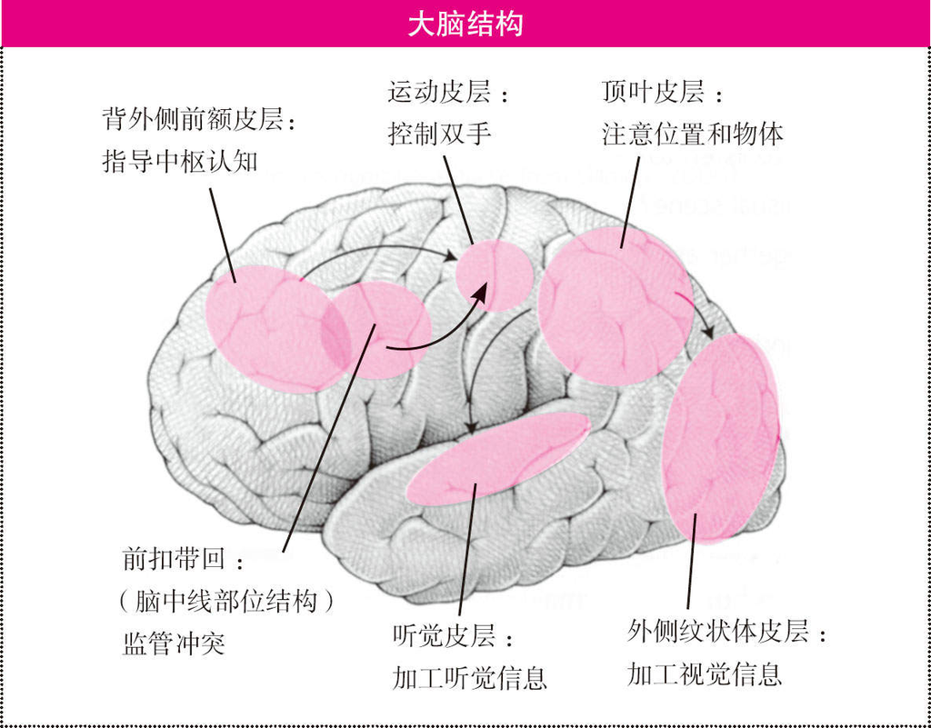

图3.1 一些与注意有关的脑区以及它们所控制的一些知觉和运动区。顶叶区域在引导知觉资源方面特别重要，前额叶区域（背外侧前额皮层，前扣带回）在执行控制方面特别重要。

◎注意系统在顺序瓶颈处选择待加工的信息，顺序瓶颈指的是不可能平行加工信息的地方。

## 听觉注意

有关注意的一些早期研究主要集中于听觉注意。大部分这些研究都是围绕双耳分听任务 （dichotic listening task）进行的。在图3.2所示的一项典型的双耳分听实验中，被试戴着一副耳机。他们会同时听到两条信息，每条信息各传入一只耳朵，要求被试“跟踪”两条信息中的一条（即仅复述来自一条信息的话语）。绝大多数被试都能够注意一条信息而忽略另一条。

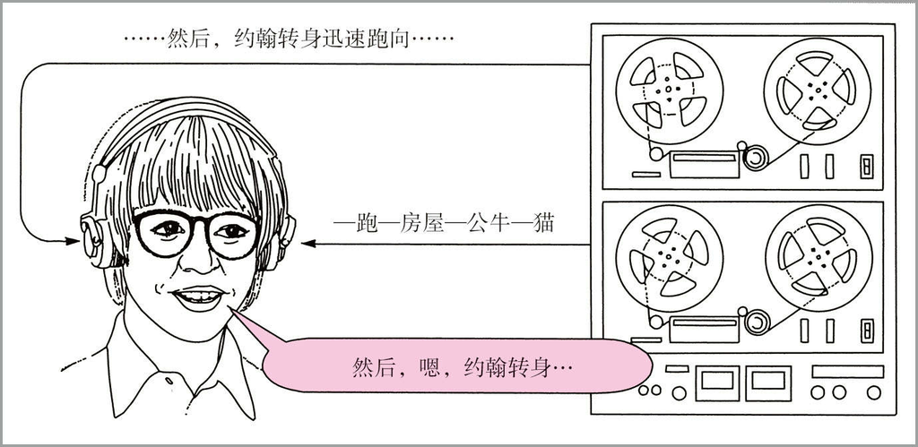

图3.2 一项典型的双耳分听任务。给被试的左耳和右耳呈现不同的信息，并要求他们“跟踪”进入一只耳朵的信息。 （资料来源：Lindsay & Norman，1977．Reprinted by permission of the publisher．©1977 by Academic Press.）

心理学家们（例如Cherry，1953；Moray，1959）发现，在双耳分听任务中，未注意的信息中仅有少量信息得到了加工。在听完信息后，被试报告他们能够分辨出未注意的信息是一个人的声音还是噪声；人的声音是男声还是女声；以及在测试过程中说话者的性别是否有所改变。这些有限信息就是他们所能报告的全部内容。他们不能说出听到的是哪种语言也记不住任何词汇，哪怕是一再重复的单词。人们常常将执行这个任务比作出席鸡尾酒会，在酒会上的客人倾听一条信息（一个交谈）而过滤掉其他信息。这是一个目标导向加工的例子，听者选择待加工的信息。但是，回到目标导向加工和刺激驱动加工的区别上，重要的刺激信息能够干扰我们的目标。我们可能都体验过这样的情况，我们正专心地听一个人讲话时，在其他人的谈论中听到了自己的名字。这种情况下很难保持我们的注意在原讲话者所讲的内容上。

### 过滤器理论

布罗德本特（Broadbent，1958）提出了过滤器理论 （filter theory）（一种早期选择理论）来解释这些结果。他的基本假设是，感觉信息在系统内穿行直到到达某个瓶颈。在那里，人们根据某些物理特征来选择待加工的信息，而过滤掉其他信息。在双耳分听任务中，假设传入每只耳朵中的信息都被记录了，但是在某个点上被试只选择一只耳朵去倾听。在鸡尾酒会上，我们根据诸如说话者的音调这类物理特征来选择倾听哪位说话者。

布罗德本特的最初的过滤器模型的一个关键特征是，他认为我们是基于像耳朵或音调等这类物理特征来选择信息进行加工的。这个假设有一定的神经生理学道理。进入每只耳朵的信息抵达不同的神经，不同神经传递的每只耳朵的声音频率有所不同 <sup>(4)</sup> 。因此，我们可以想象，脑以某种方式选择某些神经“去注意”。

人们当然能够根据信息的物理特征来选择要注意的信息。然而，有证据表明，我们还可以根据语义内容来选择信息进行加工。在一项研究中，当时还是牛津大学本科生的格雷和韦德伯恩（Gray & Wedderburn，1960）证明了被试成功地跟踪了在两耳之间来回切换的一条信息。图3.3给出了其实验中被试的任务。假定被试跟踪的信息中意义明确的部分是dogs scratchfleas （狗抓跳蚤 ）。传到他一只耳朵中的信息可能是dogs sixfleas （狗六跳蚤 ），而传到他另一只耳朵的信息可能是eight scratch two （八抓二 ）。要求被试跟踪意义明确的信息，他们会报告dogs scratchfleas （狗抓跳蚤 ）。因此，被试能够根据语义而不是根据每只耳朵所听到的物理特征来跟踪信息。

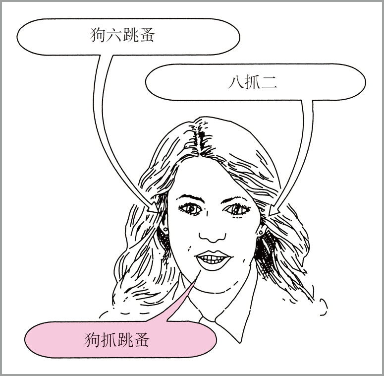

图3.3 格雷和韦德伯恩（Gray & Wedderburn，1960）实验中的一项跟踪任务。被试跟踪在两耳之间转移的意义明确的信息。 （资料来源：Klatzky，1975．Adapted by permission of the publisher．©1975 by W．H．Freeman.）

特雷斯曼（Treisman，1960）观察了要求被试跟踪一只特定耳朵的情况（图3.4）。被跟踪的耳朵中的信息在一定的时间内意义明确，然后就变成任意排列的单词串。与此同时，意义明确的信息转移至另一只耳朵，也就是被试一直未注意听的那只耳朵。有些被试违背了要求，转换到另一只耳朵继续追随意义明确的信息。其他的被试则仍然继续追随之前跟踪的耳朵。因此，人们似乎有时用身体的耳朵来选择要跟随的信息，有时则按语义内容来选择。

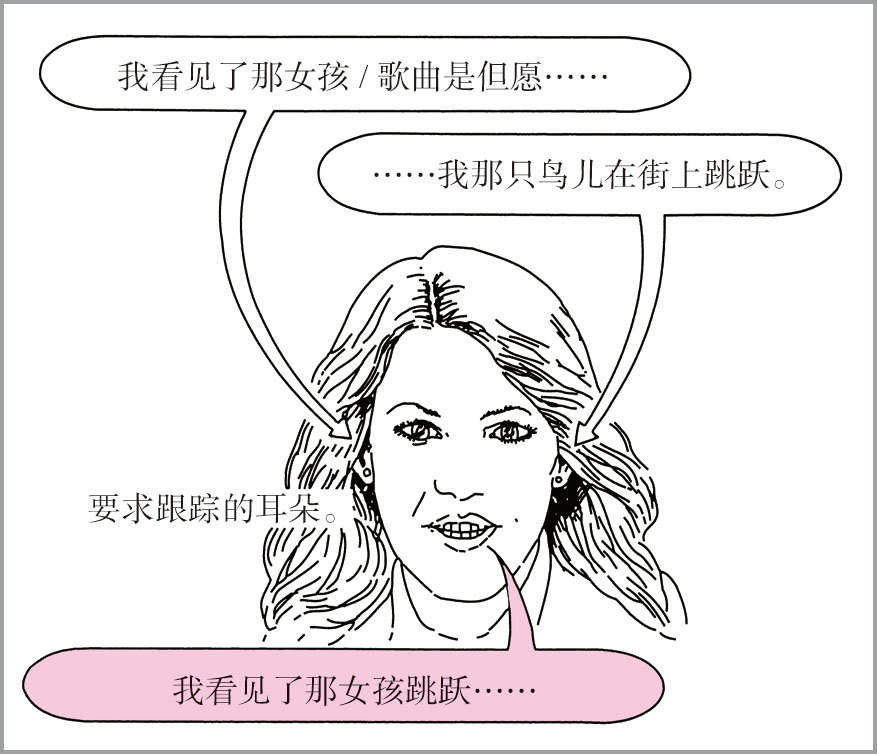

图3.4 特雷斯曼（Treisman，1960）的实验示意。意义明确的信息转移至另一只耳朵，被试有时会违背要求继续跟踪它。 （资料来源：Klatzky，1975．Adapted by permission of the publisher．©1975 by W．H．Freeman..）

◎布罗德本特的过滤器模型认为，我们使用物理特征例如耳朵或音调来选择待加工的信息，但是实验显示人们也能把语义内容作为选择的基础。

### 衰减理论与后期选择理论

为了解释这些结果，特雷斯曼（1964）对布罗德本特的模型进行了修正，提出了衰减理论 （attenuation theory）。这个模型假设，根据其物理特性某些信息会被削弱但不会被完全过滤掉。因此，在双耳分听任务中，被试将来自未被注意的耳朵的信号减至最弱，但并未完全消除掉。语义选择标准能够运用于所有信息，而不管它们是否被衰减。如果信息被衰减，那么运用语义选择标准会比较困难，但还是有可能的，正如格雷和韦德伯恩（Gray & Wedderburn，1960）的实验所示。特雷斯曼（个人交流，1978）强调，在她1960年的实验中，大多数被试实际上继续跟踪规定的耳朵。追随未被衰减的信息要比运用语义标准将注意转移至被衰减的信息容易。

另一种解释由J．A.多伊琦和D.多伊琦（J．A．Deutsch & D．Deutsch，1963）在他们的后期选择理论中提出。他们认为，所有信息都未被衰减而得到了完全加工。他们假设，能力局限性存在于反应系统中而不是知觉系统中。他们认为，人们能够知觉多条信息，但是，他们每次只能跟踪一条信息。因此，人们需要某些依据来选择一条信息进行跟踪。如果被试使用意义作为判断标准（不论是遵循实验要求还是违反要求），他们将变换耳朵去追随有意义的信息。如果被试使用初始的耳朵来决定要注意的信息，他们将会跟踪被选择的那只耳朵。

两种理论之间的区别如图3.5所示。两个模型都认为在加工过程中存在过滤器或瓶颈。特雷斯曼的理论（如图3.5a所示）认为过滤器选择加以注意的信息，而多伊琦和多伊琦的理论（如图3.5b所示）却认为过滤器在知觉刺激经过了言语内容的分析后才起作用。特雷斯曼和格芬（Treisman & Geffen，1967）试图探讨这两个理论之间的区别。他们采用了一个双耳分听任务，在这个任务中，被试必须跟踪一条信息，并且还必须为一个目标词而对双耳的信息都进行加工。如果他们听见了目标词，他们就轻拍作出暗示。根据多伊琦和多伊琦的后期选择理论，来自双耳的信息都会得到处理，被试应该能够同样好地觉察出来自两只耳朵的关键词。相反，衰减理论则会预期由于信息在非跟踪耳中被衰减，所以对关键词的觉察就要差得多。在实验中，被试觉察出了来自跟踪耳的87％的目标词，而只觉察出了来自非跟踪耳的8％的目标词。与衰减理论相一致的其他证据由特雷斯曼和赖利（Treisman & Riley，1969）以及由约翰斯顿和海因茨（Johnston & Heinz，1978）所报告。

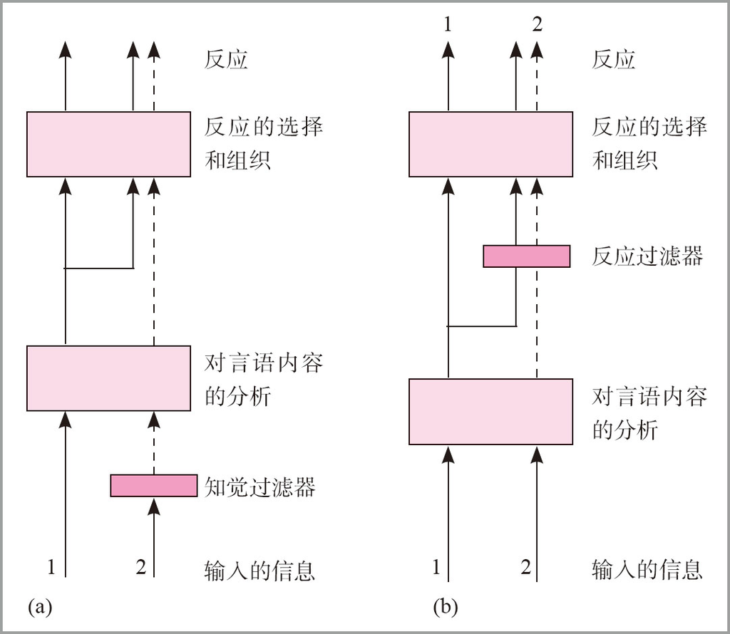

图3.5 由特雷斯曼和格芬制作的注意局限性对比图。（a）特雷斯曼（1964）的衰减理论，（b）多伊琦和多伊琦（1963）的后期选择理论。 （资料来源：Treisman & Geffen，1967．Reprinted by permission of the publisher．©1967 by the Quarterly Journal of Experimental Psychology .）

神经学证据支持了衰减理论，这个理论断言既存在来自注意耳的信号的增强，又存在来自非注意耳的信号的衰减。初级听觉皮层（参见图3.1）对来自听者注意耳的听觉信号的反应增强，而对来自另一只耳朵的信号的反应减弱。沃尔多夫等（Woldorff et al.，1993）通过ERP记录发现，这些反应发生在刺激呈现后的20～50毫秒之间。听觉加工中这种增强反应早在识别信息中的语义之前就发生了。还有证据表明，听觉皮层中信息的增强是基于特征而不是位置。例如，扎托利等人（Zatorre，Mondor，& Evans，1999）在一项PET研究中发现，当人们根据音调来注意某条信息时，在听觉皮层中出现了类似的增强（被记录为激活增强）。这项研究还发现，在引导注意的顶叶区也出现了激活的增强。

虽然听觉注意能够增强初级听觉皮层中的活动，但是，尚无可靠的证据支持在听觉加工的更早期阶段，如在听觉神经或在脑干中的加工存在注意效应（Picton & Hillyard，1974）。我们所讨论过的各种结果表明，初级听觉皮层是最先受注意影响的区域。我必须强调，对听觉皮层的影响是衰减和增强的关系。信息并没有被完全过滤掉，因此仍然可能在后期加工阶段选择它们。

◎注意能够增强或减弱对初级听觉皮层中的听觉信号的反应幅度。

## 视觉注意

视觉加工中的瓶颈现象甚至比听觉信息加工中的更加明显。正如我们在第2章所看到的，视网膜不同区域的视敏度不同，其中一个叫做中央凹的非常小的区域的视敏度最大。虽然人的眼睛会记录视野中一大片区域的信息，但是，中央凹只记录视野中的一小部分。因此，在我们选择将自己的视力集中于何处的过程中，我们也在选择将我们的大部分视觉加工资源投向视野的特定部分，并减少对加工视野其他部分的资源分配。通常，我们会专注于我们正在注视的那部分视野。例如，当我们阅读时，我们会移动眼睛以便能注视正在注意的词汇。

然而，视觉注意的焦点并不总是与中央凹正在加工的视野部分一致。人能够按指导语注视视野的一个部分（使这部分成为中央凹的焦点），却注意视野非中央凹区的其他部分 <sup>(5)</sup> 。在一项实验中，波斯纳等人（Posner，Nissen，& Ogden，1978）让被试注视一个固定点，然后向他们呈现位于这个注视点左侧或右侧7°处的一个刺激。在一些测试中，告诉被试刺激可能出现在哪一侧；而在另外的测试中，则没有这种提示。当有提示时，80％的提示是正确的，而有20％的提示与刺激出现的一侧相反。主试监测眼动，只有双眼停留在注视点处的那些测试的数据有效。图3.6分别显示了不同条件下对刺激做出判断所需的时间：刺激出现在预期的位置（概率为80％）；未向被试提示刺激出现的位置（概率为50％）；刺激出现在意外的位置（概率为20％）。被试能够将注意从眼睛所注视的位置处转移开：当刺激出现在预期位置时，他们对刺激的反应较快；当刺激出现在意外的位置时，他们对刺激的反应则较慢。

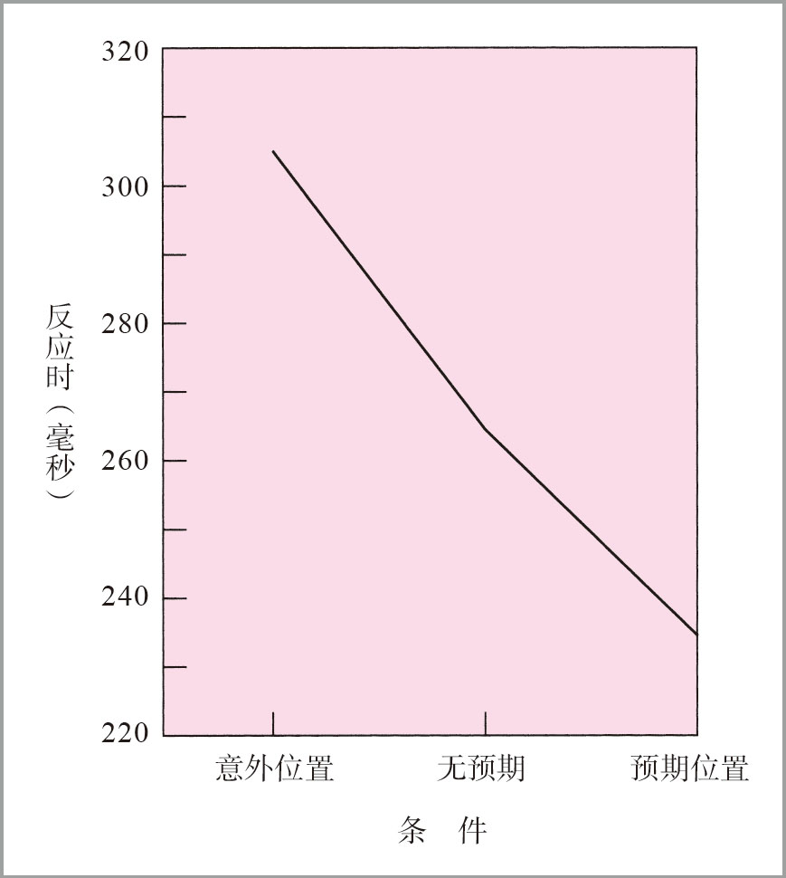

图3.6 确定人们如何对出现在注视点左右各7°处的刺激做出反应的实验结果。曲线图表示被试对于出现在预期的、意外的以及中性的（没有预期位置）信号的反应时间。 （资料来源：Posner，Nissen，& Ogden，1978．Reprinted by permission of the publisher．©1978 by Erlbaum）

波斯纳等人（Posner，Snyder，& Davi-dson，1980）发现，人们能够注意距中央凹远达24°处视野的区域。虽然人们能够在未伴随眼动的情况下转移视觉注意，但是人们通常还是会移动他们的眼睛，以便使中央凹加工他们正在注意的那部分视野。波斯纳（Posner，1988）指出，对眼动的有效控制要求我们注意中央凹以外的部位。也就是说，我们必须注意和识别一个感兴趣的非中央凹区域，才能使我们双眼注视这个区域，从而以最佳精度对它加工。因此，注意的转移通常发生在相应的眼动之前。

为了加工复杂视觉情景，我们必须在视野内转换注意以追踪视觉信息。这个过程与跟踪某个交谈过程相似。奈塞尔和贝克勒恩（Neisser & Becklen，1975）进行了一个类似听觉跟踪任务的视觉跟踪实验。他们让被试观看彼此叠映在一起的两个录像。其中一个是两人在玩拍手游戏，另一个是一些人在打篮球。图3.7显示了呈现给被试的场景。他们要求被试注意其中的一部影片，并且注意影片中的怪异情节，例如拍手游戏过程中两位游戏者双手暂停和相握。被试能够注意观看一部影片，并报告说能过滤掉另一部影片。当要求被试注意观看两部影片中的怪异情节时，他们则感到非常困难并丢失了许多关键情节。

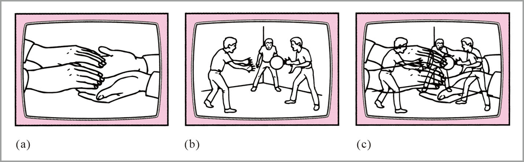

图3.7 奈塞尔和贝克勒恩（Neisser & Becklen，1975）在他们的类似于听觉跟踪任务的视觉跟踪任务中所使用的两部录像的画面。（a）“拍手游戏”；（b）打篮球；（c）两部影片叠加。 （资料来源：Neisser & Becklen，1975．Reprinted by permission of the publisher．©1975 by Academic Press .）

正如奈塞尔和贝克勒恩（Neisser & Becklen，1975）所指出的那样，这种情况涉及到使用物理线索和使用内容线索的有趣结合。被试移动双眼和聚焦他们的注意，使得被跟踪事件的关键部分落在中央凹和注意的聚焦中心。另一方面，他们要想知道如何移动双眼追随某个事件的唯一方法就是参照正在加工事件的内容。因此，物理线索促进他们对关键影片进行加工，而对关键影片的加工，又促进他们提取内容，使他们知道目光要移向哪里。

奥克雷文等人（O'Craven，Downing，& Kanwisher，1999）研究了面对重叠的刺激时，被试注意一个目标或另一个目标时的神经活动，图3.8是实验材料的一个例子。被试看到一系列人脸叠加在房子上的图片，实验者要求他们看出重复的人脸或重复的房子。回想第2章介绍过的一个梭状回区域，梭状回脸部区，当人们观察脸部时它有较强的激活。颞叶皮层有另一个区域，海马旁回位置区，在人们观察地点位置时会被激活。面对这些由人脸和位置共同组成的图片会发生什么特别的事吗？哪个脑区会被激活？梭状回脸部区还是海马旁回位置区？正如读者可能猜测的那样，答案依赖于被试所注意的对象。当被试寻找重复的人脸时，梭状回脸部区有更强的激活；当他们寻找重复的位置时，海马旁回位置区有更强的激活。注意能够选择颞叶皮层的哪个区域参与刺激加工。

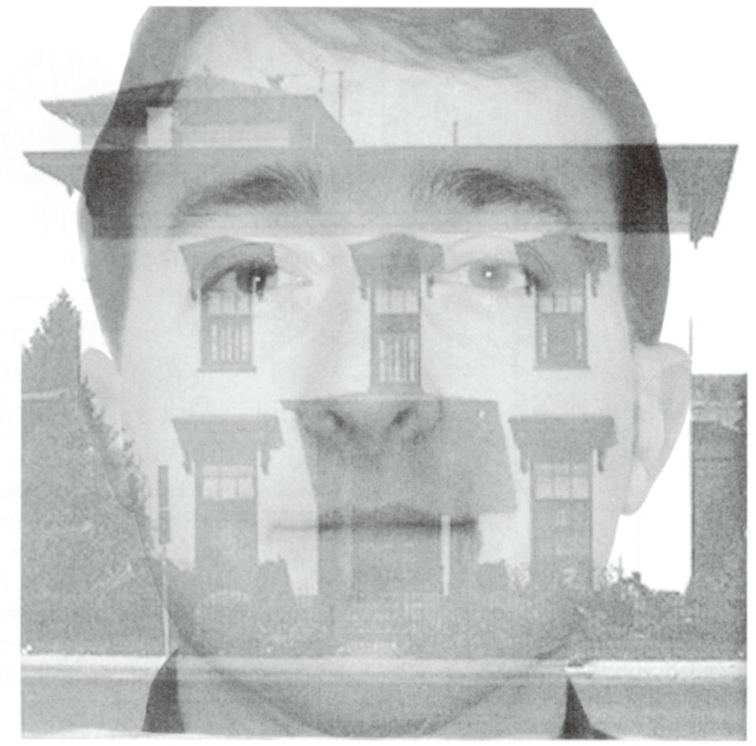

图3.8 奥克雷文等人（O'Craven et al.，1999）研究中所使用的图片的例子。当人脸被注意时，梭状回脸部区有激活，而当房子被注意时，海马旁回位置区有激活。

◎人们能够将注意集中在视野的某一部分上，并且能够转移注意焦点去处理他们感兴趣的事物。

### 视觉注意的神经基础

看起来构成视觉注意基础的神经机制与构成听觉注意基础的神经机制非常相似。正如集中于一只耳朵的听觉注意可增强来自这只耳朵的大脑皮层信号那样，集中于某一空间位置的视觉注意似乎也能增强来自这一区域的大脑皮层信号。如果一个人注意某个特定的空间位置，在刺激呈现后的70～90毫秒内视皮层就会出现明显的神经反应（从ERP记录中看到）。另一方面，当一个人注意的是特定物体（比方说，注意椅子而不是桌子）而不是某个特定空间位置时，到刺激呈现后200多毫秒，我们也看不到有反应。因此，正如听觉注意那样，基于内容的注意似乎比基于物理特征的注意需要付出更多努力。

曼根等人（Mangun，Hillyard，& Luck，1993）让被试注视计算机屏幕的中央，然后要他们判断出现在与注视位置不同的几个位置（左上，左下，右上，右下）的柱条长度。他们记录了头皮后部不同位置处的ERP。图3.9给出了被试正在注意视觉阵列的四个不同区域之一（眼睛注视屏幕中心）时头皮活动的分布。与视皮层的拓扑结构一致，在出现目标刺激的视野的对侧，头皮的活动最强。回顾第1章与第2章（见图2.6 ）可以知道，视皮层（在头的后部）是按拓扑结构方式组织的，它将左右视野表征在大脑半球的对侧区域。因此，与视觉注意位置相对应的视皮层部分的神经加工似乎得到了增强。

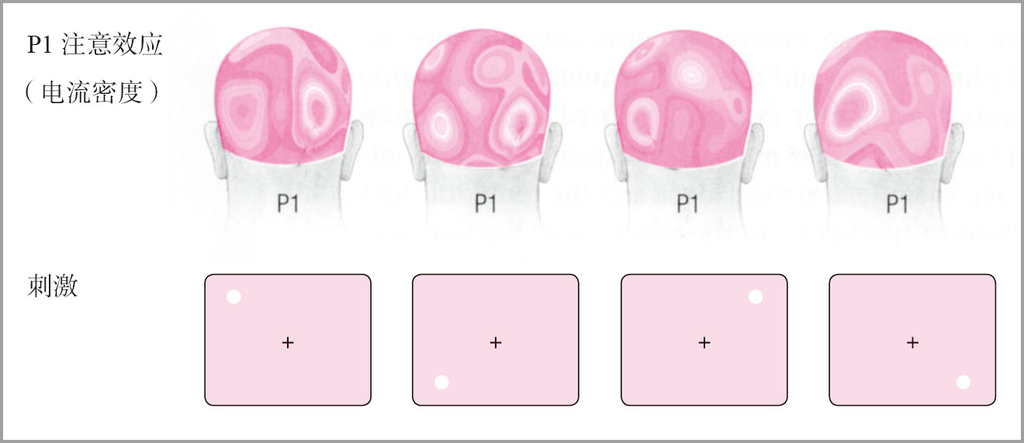

图3.9 曼根、希利亚德和勒克的实验结果。图为当注视点在屏幕中心时，通过ERP记录的被试注意视野矩阵中不同位置的区域时的头皮活动。记录到的最强活动出现在呈现刺激的视野的对侧头皮，证实了与视觉注意位置对应的视皮层部分出现了增强的神经加工。 （资料来源：Mangun et al.，1993．Adapted by permission of the publisher．©1993 by MIT Press.）

罗尤西玛等人（Roelfsema，Lamme，& Spekrejse，1998）研究了信息加工的视觉注意对恒河猴的初级视觉区的影响。他们训练猴子完成如图3.10所示的相当复杂的任务。实验的一次测试，由猴子注视视野中的一个特定刺激开始，如图a所示。随后出现了两条曲线，如图b所示，其中只有一条线将初始目标和注视点相连。猴子必须保持注视该点600毫秒，然后眼跳将视线转移到连接初始刺激的曲线的末端（图c）。当猴子执行这项任务时，罗尤西玛等人记录了猴子的初级视觉皮层细胞（已经知道这里的细胞有如图2.8所示的感受野）。图3.10中的方块代表其中一个细胞的感受野。当一条线落在视野中的这个部位时，这个细胞的反应增加；当一条曲线通过这个部位时，这个细胞的反应也增加。当感受野位于连接注视点和目标点的曲线上时，细胞在600毫秒等待时间里的反应比当感受野位于其他曲线上时更大。猴子必须沿着曲线转移注意以决定将目光扫向哪里，这种转移使V1区的线条觉察器反应更强烈。

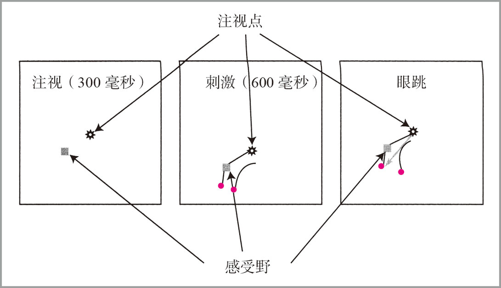

图3.10 罗尤西玛等人（1998）的实验程序：（a）猴子注视起点。（b）出现两条曲线，其中一条连接着起点和目标点。（c）猴子将目光转移到目标点。方块表示初级视觉皮层V1的感受野。

◎当人们注意某个特定的空间位置时，与该位置对应的视皮层的神经活动增强。

### 视觉搜索

不论是在视觉范围内还是在听觉范围内，人们能够根据物理特性，特别是根据位置，选择要注意的刺激。虽然基于简单特征的选择能在视觉系统中较早和较快地发生，但是并不是人们在寻找的任何事物都能用简单特征来界定。他们如何利用一些特定的较高层次的特征来发现一个物体，例如在人群中发现一个朋友的脸？在这种情况下，看起来他们必须搜索人群中的面孔以找到具有特定特征的人。许多有关视觉注意的研究都集中于人们是如何进行这种搜索的。然而研究者倾向于采用较简单的材料，而不是在人群中寻找面孔。例如，图3.11显示了奈塞尔（Neisser，1964）在早期的一项研究中采用的部分材料。在所呈现的字母阵列中试图找到第一个K 。

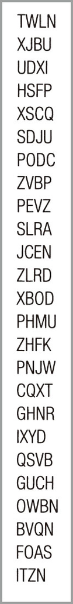

图3.11 奈塞尔的搜索实验中所采用的字母阵列的第7-31行。 （资料来源：Neisser，1964．Adapted by permission of the publisher．© 1964 by ScientificAmerican.）

很可能你会一行一行扫描这些字母来找寻目标K 。图3.12给出了在奈塞尔的实验中，被试为找到这个字母平均花费的时间，它是该字母所在行的函数。图中，函数的最佳拟合斜率约为0.6，它表示被试扫描每一行大约花了0.6秒。当人们进行这些搜索时，他们都将注意高度集中于搜索过程。例如，脑成像实验发现在这样的搜索过程中顶叶皮层有很强的激活（综述见Kanwisher & Wojciulik，2000）。

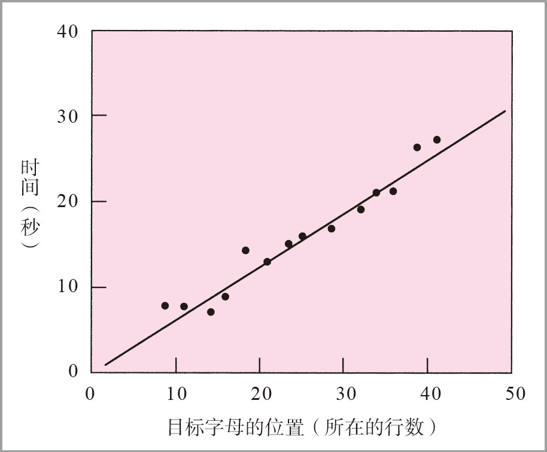

虽然，搜索可能是费力而困难的，但是，事情并非总是如此。有时我们可以轻易找到我们正在寻找的东西。如果我们知道朋友穿着一件鲜红色的夹克衫，而且假定没有其他人穿鲜红色的夹克衫，那么在人群中找到他就相对容易些。我们的朋友会自己从人群中冒出来。确实，如果在一片白色的外套中间只有一件红色的外套，那么即使我们没有刻意去寻找，它也仿佛自己跃出来一样——刺激驱动注意。如果在阵列中有一些独特的特征，似乎我们不经过搜索就可以找到它。

特雷斯曼一直对这种跃出进行着研究。例如，特雷斯曼和格拉德（Treisman & Gelade，1980）要求被试在由30个字母I 和Y 组成的阵列中找出一个字母T （如图3.13a）。他们推断，被试能够简单地通过搜寻将字母T 与I 和Y 明显区分开来的上横杠来找到T 。被试平均花了大约400毫秒时间来完成这个任务。特雷斯曼和格拉德还要求被试从由字母I 和字母Z 组成的阵列中找出字母T （如图3.13b）。在这个任务中，他们不能只使用字母T 的垂直笔画或水平笔画，他们必须寻找这些特征的连接，并且要进行模式识别中所要求的特征组合操作。在这种情况下，被试平均花费了超过800毫秒的时间才找到这个字母。因此，与只要知觉单一特征就能完成的任务相比，要求识别特征组合才能完成的任务要多花费约400毫秒的时间。此外，当特雷斯曼和格拉德改变阵列中的字母数量时，他们发现，在要求识别特征集合的任务中，被试受阵列大小的影响要强烈得多。图3.14显示了这些结果。

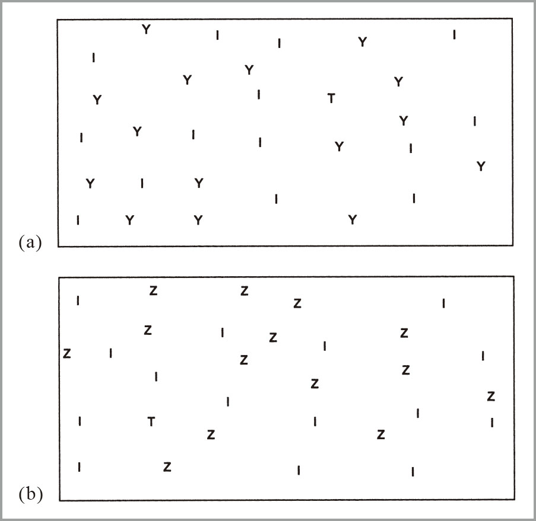

图3.13 特雷斯曼和格拉德为确定人们如何辨别视野中的目标所使用的刺激。任务是从一组干扰字母中挑选出目标字母（T）。他们发现（a）如果目标字母有一个特征使它能很容易与干扰字母（I和Y）区分开的话，任务相对容易；（b）而目标字母所处的干扰字母（I和Z）阵列中不具有与它明显不同的区分性特征时，则任务相对较难。 （资料来源：Treisman & Gelade，1980．Adapted by permission of the publisher．©1980 by Cognitive Psychology.）

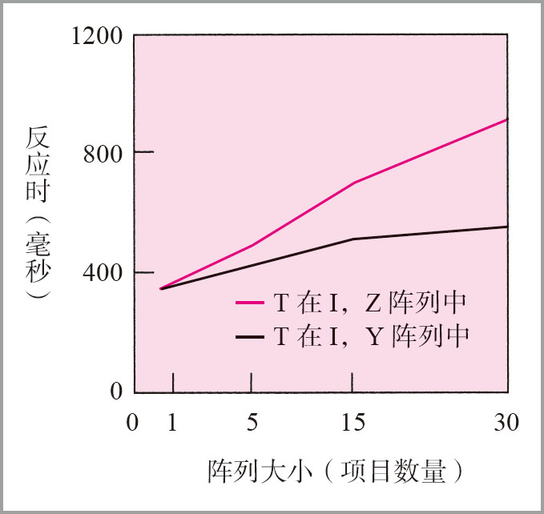

图3.14 特雷斯曼和格拉德的实验结果。图中曲线表示辨认目标字母所需的平均反应时，它是干扰字母数量以及这些字母是否分别包含目标字母的全部特征的函数。 （资料来源：Treisman & Gelade，1980．Adapted by permission of the publisher．©1980 by Cognitive Psychology.）

◎只有当被寻找的物体不具备一个独有的视觉特征时，才需要逐项搜索视觉阵列。

### 捆绑问题

正如第2章中所讨论的那样，在视觉系统中存在着不同类型的神经元，它们对诸如颜色、各种朝向的线条以及运动中的物体等不同特征做出反应。我们视野中的单个物体包含许多特征，例如，一根垂直的红色线条是由一根垂直的线条和红颜色组合而成的。同一个物体的不同特征由不同神经元表征，这一事实提出了一个逻辑上的问题：这些特征是如何结合在一起以形成对物体的知觉？如果视野中只存在一个单一的物体，这将不会是一个太大的问题。我们可以设想所有这些特征都属于这个物体。但是，如果视野中有多个物体会怎么样呢？例如，假设在视野中只有两个物体：一根红色的垂直柱条和一根绿色的水平柱条。这两个物体可能导致对红色敏感的神经元冲动、对绿色敏感的神经元冲动、对垂直线条敏感的神经元冲动以及对水平线条敏感的神经元冲动。如果这些冲动同时发生，视觉系统如何知道所看到的是一根红色的垂直柱条和一根绿色的水平柱条，而不是一根红色的水平柱条和一根绿色的水平柱条？脑如何将视野中的各种特征整合在一起被称为捆绑问题 （binding problem）。

特雷斯曼（例如，Treisman & Gelade，1980）提出了她的特征整合理论 （feature-integration theory）来回答捆绑问题。她认为，人们在能够将一个刺激的特征整合成一个模式之前，必须将他们的注意集中在这个刺激上。例如，在上述例子中，视觉系统首先会将注意引导至红色垂直柱条的位置，并合成这个物体。然后，再将注意引导至绿色水平柱条处，再合成这一物体。根据特雷斯曼的观点，当人们需要整合特征以识别物体时（例如，当辨认由一根垂直线条和两根斜线条组成的字母K 时），他们必须在阵列中搜索。当只有一个单一的独有特征（如红色夹克衫或一条特殊朝向的线条）时，我们能将注意直接转移至该物体并对其进行识别，因此无需搜索。

捆绑问题并非只是个假设上的困境，它是人们实际上会经历的困扰。证据来源之一是错觉关联 （illusory conjunctions）的研究，其中被试报告的特征组合实际并未发生。例如，特雷斯曼和施密特（Treisman & Schmidt，1982）考察了对注意中心以外的刺激特征的组合情况。被试被要求报告出在视野的某一部分中闪烁的两个黑色数字是什么。这是他们的初步任务，同时也是他们的注意集中之处。而在视野的另一部分则呈现了不同颜色的字母。例如，在未被注意的视野部分处可能向被试呈现粉红色的字母T 、黄色的字母S 以及蓝色的字母N 。在被试报告出数字之后，要求他们说出所看到的任何字母以及这些字母的颜色。在他们的报告中看到特征的错觉关联（例如，一个粉红色的S ）的次数几乎与看到特征的正确组合的次数一样多。因此，看来只有当我们将注意集中到一个物体上时，我们才能够将特征组合到准确的知觉中。否则，我们虽能觉察到特征，但很有可能将它们组合成了从未出现过的物体的知觉。虽然只有在相当特殊的情况下才会在正常人身上出现错觉关联，但是，某些顶叶皮层受损的患者特别容易出现这种错觉。例如，由弗里德曼-希尔等人（Friedman-Hill，Robertson，& Treisman，1995）研究的一名患者，在一些不同颜色的字母被呈现长达10秒时，依然会将字母的颜色弄混。

已经有了许多关于将单一物体的特征捆绑在一起的神经机制的研究。视觉区域V4中的神经元有着大的感受野（视角可达若干度），一次呈现的多个物体可能会落在单个神经元的视野中。勒克等人（Luck，Chelazzi，Hiillyard，& Desimone，1997）训练恒河猴注视视野中的特定部分，并记录这一区域周围的神经元活动。他们发现神经元对应着特定类型的对象。例如，他们发现有一个细胞只对蓝色垂直柱条起反应。当一根蓝色垂直柱条和一根绿色水平柱条都呈现在这个细胞的感受中时，会发生什么情况？如果猴子注意蓝色垂直柱条，那么这个细胞的反应率会与只呈现一根蓝色垂直柱条时保持在相同的水平。另一方面，如果猴子注意集中在绿色的水平柱条上，那么这个细胞的放电频率就会大大地下降。因此相同的刺激（蓝色垂直柱条加上绿色水平柱条）会由于注意的对象不同而引起不同的反应。出现这个现象可能是由于注意抑制了对感受野内处于注意位置以外的所有其他特征的反应。在人类的fMRI实验中也得到了类似的结果。卡斯特纳等人（Kastner，DeWeerd，Desimone，& Ungerleider，1998）测量了对出现在视野某一区域的刺激做反应的视觉区域的fMRI信号。他们发现，当注意从这一区域移走时，对该区域的刺激的fMRI反应也相应减弱；但是当注意集中在这一区域时，fMRI反应也得到了保持。这些实验表明与被注意的物体和位置对应的神经活动得到了增强。

西蒙斯和查布里斯（Simons & Chabris，1999）报告了一个令人瞩目的持续注意效应的演示。他们让被试观看录像，在这段录像中身着黑色球衣的一队球员来回传递篮球，身着白色球衣的另一队球员也在来回传球（图3.15）。他们要求被试或者计算身着黑色球衣的球队投掷篮球的次数，或者计算身着白色球衣的球队投掷篮球的次数。假定在一种情况下是让被试追踪身着黑色球衣的球队所发生的事情，另一种情况下是让被试追踪身着白色球衣的球队所发生的事情。由于球员是彼此混杂在一起的，因此这个任务有点难，它需要持续集中注意。在游戏过程中，一位身穿黑色大猩猩皮毛的人穿过房间。当被试追踪身着白色球衣的球队时，他们注意到那个身着黑色大猩猩皮毛的人的次数只有8％；当他们追踪身着黑色球衣的球队时，他们注意到那个人的次数达67％。他们是如此专注地追踪录像中身着白色球衣的队员发生的事情以至于完全忽视了这一黑色对象。当人们被动地观看录像时从来没有忽视过那位身着黑色大猩猩皮毛的人。这段录像可从西蒙斯视觉认知实验室（Simons's Visual Cognition Lab）网站的演示页面获取：

http://viscog.beckman.uiuc.edu/djs_lab/demos.html

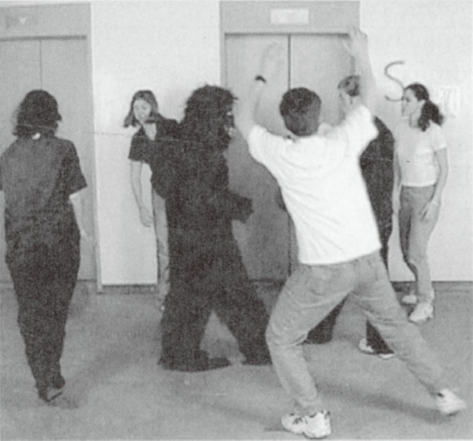

图3.15 西蒙斯和查布里斯用来演示持续注意效应的录像中的一个画面。当被试专注于追踪身着T恤衫的球员之间的传球时，他们往往不会注意到穿过房间的黑色大猩猩。 （资料来源：Simons & Chabris，1999．Reprinted by permission of the publisher．©1999 by Perception .）

◎要将特征信息整合成一个模式，必须集中注意到特征信息上。

### 视野忽视

我们已经讨论了对空间位置的视觉注意会导致初级视觉皮层相应部位的激活增强的有关证据。然而，控制这种注意转移的神经结构似乎位于其他部位。猴脑的三个区域表现出与注意的控制有关（S．E．Peterson，Robinson，& Morris，1987；Wurtz，Goldberg，& Robinson，1980）。这些区域是上丘、后顶叶和被称之为丘脑后结节的中脑区域。在人类患者中，这些区域特别是顶叶（见图3.1）的损伤会导致视觉注意缺陷。例如，波斯纳等人（Posner，Walker，Friedrich，& Rafal，1984）发现，顶叶损伤患者难以摆脱对一侧视野的注意。

右侧顶叶损伤会导致独特的缺陷模式。波斯纳等人（Posner，Cohen，& Rafal，1982）研究了一位这类患者的注意缺陷。他们给患者提示预期在注视点左侧或右侧出现的一个刺激，80％的刺激会呈现在预期的位置，然而有20％的刺激呈现在预期之外的一侧视野。图3.16给出了觉察刺激所需的时间，它是刺激呈现的视野以及提示预期的视野的函数。当刺激呈现在右视野时，如果提示不正确，患者只表现出很小的缺陷。然而，如果刺激呈现在左视野且提示不正确时，患者会表现出明显的缺陷。因为右侧顶叶加工左侧视野，一旦注意集中于右侧视野时，右侧顶叶损伤会导致将注意转至左侧视野的能力的削弱。这种单侧注意缺陷可以通过在顶叶皮层施加TMS而在正常个体身上暂时性地制造出来（Pascaul-Leone et al.，1994，见第1章关于TMS的讨论）。

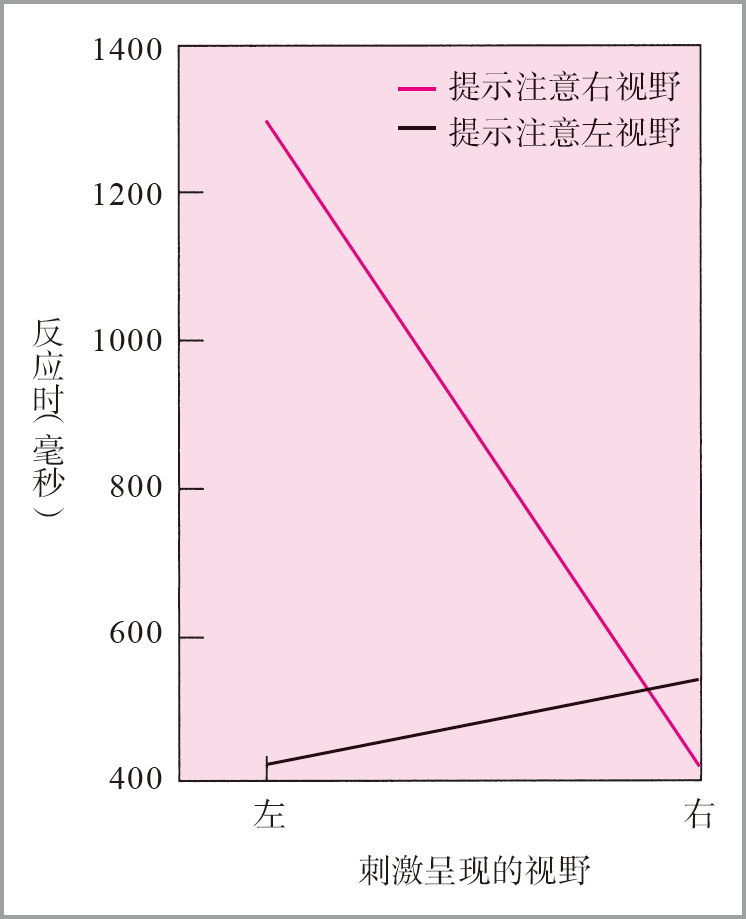

图3.16 一位右侧顶叶损伤患者将注意转向左侧视野时所表现出的注意缺陷。 （资料来源：Posner，Cohen，& Rafal，1982．Reprinted by permission of the publisher．© by the Royal Society of London.）

更加极端的一种注意缺陷被称为单侧视觉忽视。右脑半球受损的患者完全忽视视野的左侧，而左脑半球受损的患者则完全忽视视野的右侧。图3.17显示了一名患者因右脑半球受损导致的忽视左侧视野的行为（Albert，1973）。她被要求在所有圆圈上画上斜杠，我们可以看到，她忽视了左侧视野的圆圈。这样的患者经常有异常的行为。例如，一位患者不会刮半边脸的胡子（Sacks，1985）。

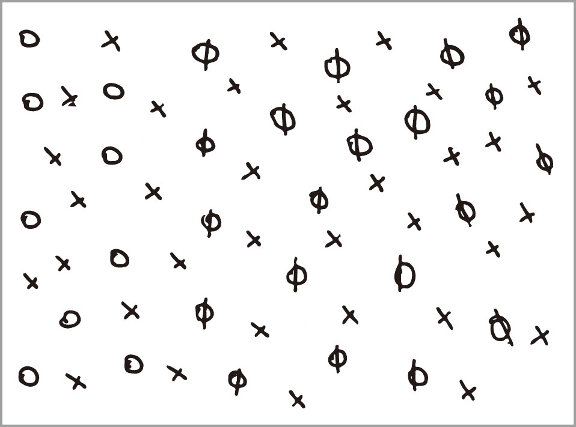

图3.17 一位右脑半球受损的患者被要求在所有圆圈上画上斜杠时的行为表现。由于右脑半球受损伤，她忽视了在左侧视野中的圆圈。 （资料来源：Ellis & Young，1988．Reprinted by permission of the publisher．© 1988 by Erlbaum.）

右侧顶叶似乎参与多种感觉通道中的空间注意分配，而不只是视觉（Zatorre et al.，1999）。例如，当一个人注意听觉或视觉刺激的位置时，右顶叶的激活增强。同时，右顶叶看起来比左顶叶更多地负责了对注意的空间分配。这就是为什么右顶叶受损往往会产生如此明显的效应，左顶叶受损往往会造成不易察觉的缺陷。罗伯逊和拉福（Robertson & Rafal，2000）认为，右侧顶叶负责注意诸如空间位置那样的整体特征，相反，左侧顶叶区则负责将注意引向物体的局部。图3.18显示了左、右顶叶受损所对应的显著不同的注意缺陷类型。患者被要求画出图3.18a中的对象。右顶叶受损的患者（图3.18b）能够复制出图片中具体的组成部分，但无法复制出它们的空间架构。相反，左顶叶受损的患者（图3.18c）能够复制整体架构，却无法复制细节。与此相似，近年的脑成像研究发现，当一个人对整体图形做出反应时，右顶叶表现出激活增强；而当一个人注意局部图形时，左半球表现出激活增强（Fink et al.，1996；Martinez et al.，1997）。

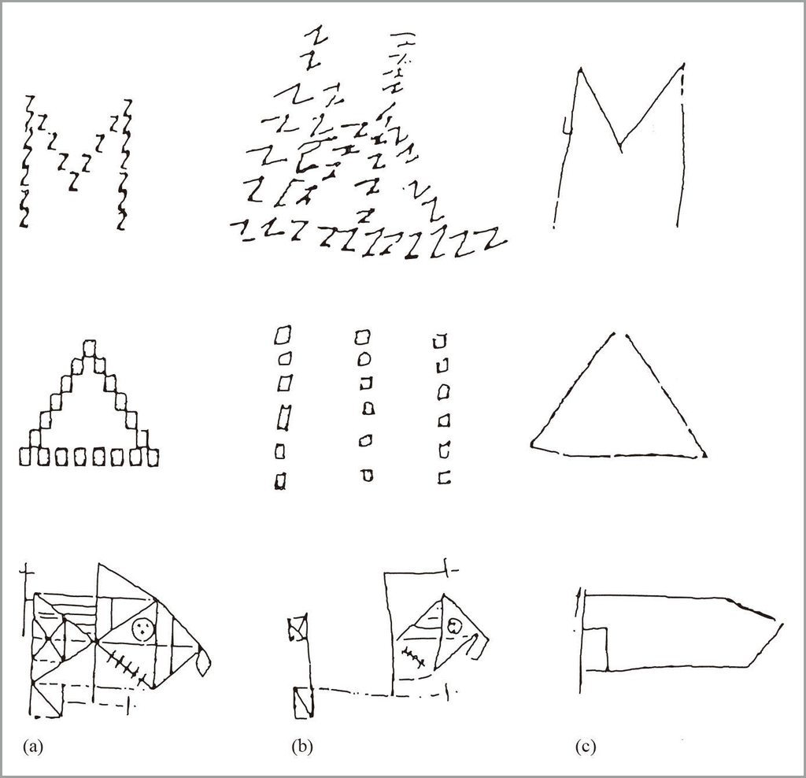

图3.18 （a）呈现给顶叶损伤病人的图片。（b）右半球损伤的病人画出的图画。这些病人能够复制出图片中的具体组成成分，但是无法复制出空间架构。（c）左半球损伤的病人画出的图画。这些病人能够复制出整体架构，但是无法复制出细节。 （资料来源：Robertson & Lamb，1991．Adapted by permission of the publisher．©1991 by Cognitive Psychology .）

◎顶叶负责注意的分配，右脑半球更多地负责整体特征，而左脑半球则更多地负责局部特征。

### 基于物体的注意

到目前为止，我们探讨了基于空间的注意，也就是人们将注意放在了某个空间位置上。然而还有证据表明，存在着一种基于物体的注意，也就是人们将注意集中在特定的物体上而不是空间位置上。以贝尔曼等人（Behrmann，Zemel，& Mozer，1998）的研究为例，他们发现有时人们注意一个物体比注意一个位置更容易。图3.19显示了在实验中所使用的一些刺激。他们要求被试判断位于这些物体两端的突起数是否相同。左边一列是突起数相同的例子，右边一列是突起数不同的例子。当突起位于相同物体上时（图3.19中最上边和最下边一行），被试做出判断要快于突起位于不同物体上的情况（图3.19中的中间一行）。尽管突起位于不同物体时，它们靠得更近一些，应当更有助于做出判断，但是仍然得到了上述结果。贝尔曼等认为，被试能一次将注意转移到一个物体上，而不是一个空间位置上。因此，当突起全都位于相同的物体上时，被试无需在物体之间转移注意。

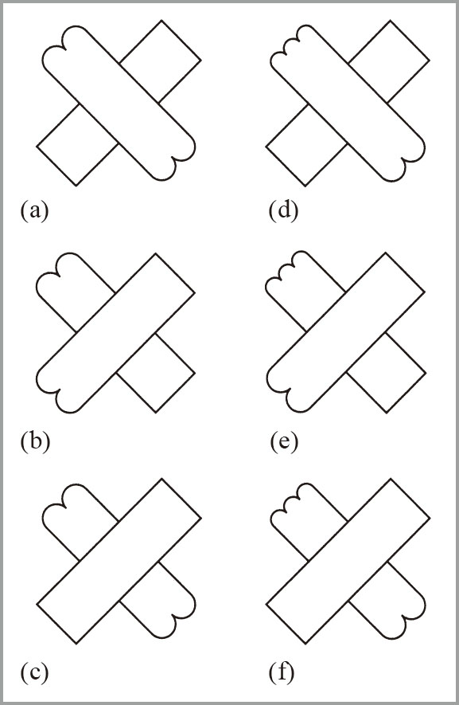

图3.19 贝尔曼、泽梅尔和莫泽尔实验中所使用的刺激。这个实验表明有时注意一个物体比注意一个位置更容易。左右两列分别表示相同和不同的判断，从上到下的各行分别表示单一物体，两个物体，及有遮蔽的情况。 （资料来源：Behrmann，Zemel，& Mozer，1998．Reprinted by permission of the publisher．©1998 by the Journal of Experimental Psychology；Human Perception and Performance .）

另一支持以物体为中心的注意的证据涉及被称为返回抑制 （inhibition of return）的现象。如果我们已看过空间的某个特定区域，我们会发现很难再将我们的注意转回到该区域。人的这种行为是有其道理的：如果我们正在找寻一个东西，并且已经搜索过某个位置，我们宁愿到其他地方去寻找，而不是再回到已经搜寻过的位置。如果我们将眼睛移向位置A然后到位置B，那么我们将眼睛转回位置A将比移向某个新位置C要慢。当我们不移动眼睛而转移注意时，情况也是如此（Posner，Rafal，Chaote，& Vaughn，1985）。

蒂珀等人（Tipper，Driver，& Weaver，1991）的一项返回抑制的实验也为基于物体的注意提供了证据。在他们的实验中，被试观看一个方框中的3个实心方块，类似于图3.20所示。在一种情况下，这些方块不移动（不像图3.20所示的运动情况，对此我们将在下一段落中讨论）。通过使外侧的一块方块闪烁，将被试的注意吸引至该方块上。200毫秒后，通过使中间方块闪烁，使注意回到中间方块上。然后一个探测刺激出现在两个外侧位置中的一个地方，要求被试按键表示他们看见了探测刺激。当探测刺激出现在未闪烁过的外侧方块上时，他们平均用420毫秒看到它；而当探测刺激出现在已经闪烁过的外侧方块上时，他们却要用460毫秒才能看到它。这40毫秒的优势是空间返回抑制的例证。人们在将注意转移到已经注意过的位置时会比较慢。

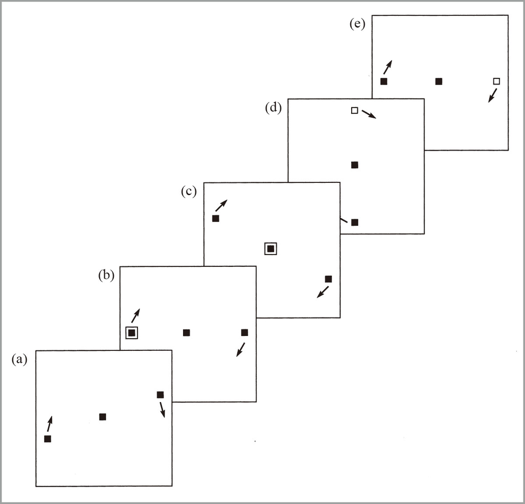

图3.20 蒂珀、德赖弗和韦弗实验中方框的例子，这个实验是用来确定返回抑制是针对特定物体还是针对它所处的位置的。箭头表示移动。（a）显示为起始状况，呈现500毫秒后方块开始移动。经过两个移动画面后，三个涂黑的方块呈水平排列（b），接着出现提示（其中一个方块闪烁）*。随后，顺时针方向继续移动下去，提示呈现在最初的三个画面的中心位置上（c-e）。外侧的方块继续顺时针移动（d）直到水平排列成行为止（e），在这一刻呈现一个探测刺激，与前面一样（其中一个方块闪烁）。 ［*（d）和（e）中的空白方块指的是（b）中闪烁过的方块，被试在实验中看到的仍然应是实心方块。］（资料来源：Tipper，Driver & Weaver，1991．Reprinted by permission of the publisher．©1991 by the Quarterly Journal of Experimental Psychology .）

基于物体的注意的另一个例证来自对视觉忽视的研究。我们在前面谈到一些右侧顶叶受损的患者在觉察来自视野左侧的信息时会感到困难（参见图3.17）。研究者发现，不管物体出现在哪一侧视野中，有许多患者会忽视物体的左侧（Behrmann & Moscovitch，1994；Driver，Baylis，Goodrich，& Rafal，1994）。

看来视觉系统既能将注意引向空间位置又能指向物体。刚才介绍的这些实验表明视觉系统能够追踪物体。另一方面，也有许多实验表明，人们能够将注意指向没有物体的空间区域（参见图3.6所示实验的结果）。有趣的是，左侧顶叶似乎更多地参与基于物体的注意，而右侧顶叶则更多地参与基于位置的注意。左侧顶叶受损的患者表现出集中注意物体方面的缺陷（Egly，Driver，& Rafal，1994），而不是我们介绍过的右侧顶叶受损的患者所表现出的基于位置的注意缺陷。另外，当脑部未受损的被试注意物体而不是注意位置时，fMRI显示左侧顶叶表现出了较强的激活（Arrington，Cart，Mayer，& Rao，2000）。这与我们前面介绍过的（参见图3.18）右侧顶叶负责对整体特征的注意，而左侧顶叶负责对局部特征的注意的研究似乎相一致。

◎视觉注意既能指向物体而不论其置于何处，也能指向空间位置而不论其置有何物。

## 中枢注意：选择所要追随的思路

到目前为止，本章已探讨了人们如何分配注意去加工来自视觉通道和听觉通道中的刺激。在刺激被注意到并被编码后的认知会怎样呢？我们是如何选择所要追随的思路的？假设我们正在一条高速公路上开车，并且已经对一条狗正坐在道路中央这一事实进行了编码，我们可能想知道为什么这条狗会坐在那儿，我们也许会考虑是否应该做些事来帮助这条狗，同时我们肯定会考虑如何操纵好方向盘以避免发生事故。我们能同时做所有的这些事情吗？如果不能，我们是如何选择怎样操纵好方向盘这一最重要的问题，而将其余的问题留待以后去处理的？看来人们会使用与在竞争的物体中选择知觉注意对象相似的方法，在相互竞争的思路间选择中枢注意的对象。

在许多（但并不是所有的）情况下，人们每次只能追随一条思路。本部分将介绍两项实验室任务：在一项实验中，人们似乎不能同时执行两个任务，而在另一项实验中他们几乎完全有能力同时执行两个任务。然后我们将讨论人们是如何开发同时执行多个任务的能力的，以及当他们不能或不愿意同时执行多个任务时，他们是如何在这些任务中进行选择的。

第一项实验是由迈克·伯恩和我做的（Byrne & Anderson，2001）。实验证实了本章开头提出的关于不可能同时对两个数进行乘法和加法运算的断言。在本实验中被试会看到如“3 4 7”这样的三个数字串，他们可能被要求完成两个任务：

- 任务1：判断前两个数字相加是否等于第三个数字，如果是，用右手食指按下一个键；如果不是，用左手食指按另一个键。
- 任务2：口头报告第一个数与第三个数的乘积。在这种情况下，答案是21，因为3×7＝21。

被试或者被要求分别执行这两个任务或者被要求同时执行这两个任务。图3.21比较了在执行单个任务的情况下与在执行双重任务的情况下完成每一个任务所需的时间。当被试不得不同时执行两个任务时，他们几乎要花双倍的时间来完成这个任务 <sup>(6)</sup> 。图中还显示出被试在执行双重任务的情况下完成两个任务所花费的时间。（他们有59％的次数先回答乘法题，有41％的次数先回答加法题。）图3.21中靠近图顶端的水平黑线代表他们在任一种情况下得出第二个答案所花费的时间。这条线反映出了完成两个任务所需的平均时间（1.99秒）。请注意，这个时间比单独完成加法任务所需时间（0.88秒）和单独完成乘法任务所需时间（1.05秒）的总和还要多。额外花费的时间可能反映了注意在任务之间转移所需的时间（综述见Monsell，2003）。无论怎样，被试似乎根本就不可能同时做加法和乘法运算。

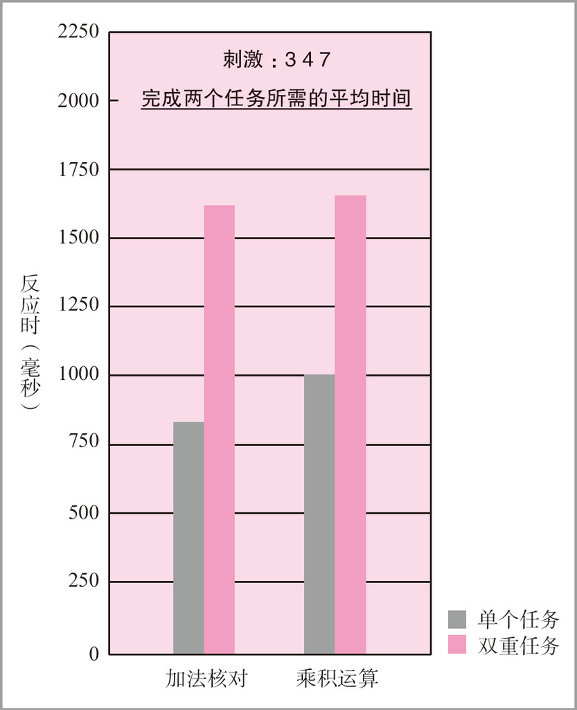

图3.21 伯恩和安德森所做的考察人们是否能同时完成两个任务的实验。柱状图表示解决两个问题，一个加法题和一个乘法题所需的反应时，包括了单独解决每个问题的反应时和同时解决这两个问题的反应时。结果表明，被试无法同时进行加法和乘法运算。 （资料来源：Byrne & Anderson，2001．Reprinted by the permission of the publisher．©2001 by Psychological Review .）

第二项实验是由舒马赫等报告的（Schumacher et al.，2001）。这项实验显示了被称为完全时间分享 （perfect time-sharing）的现象。实验任务比伯恩和安德森（Byrne & Anderson，2001）的实验任务简单得多。被试同时看屏幕上的单个字母和听一个纯音。与第一项实验相同，被试必须执行两个任务：

- 任务1：根据字母出现在屏幕的左边、中间或右边，相应地按下左键、中键或右键。
- 任务2：根据声音是低频、中频或高频，报告‘1’、‘2’或‘3’。

图3.22比较了在单个任务情况下和双重任务情况下执行每个任务所需的时间。可以看到，这些时间几乎未受到需要同时执行两个任务的影响。这项任务与伯恩和安德森的任务之间存在着许多差别。或许最明显的差别在于任务的复杂性。在第二项实验中被试能在几百毫秒内完成单个任务，而在第一项实验中却需要花大约1秒来完成单个任务。因此，第一项实验显然需要较多的思考，而人们要同时置身于两束思维流中显然比较困难。此外，第二项实验中的被试是在经过五轮练习之后，才实现了完全时间分享。而在第一项实验中则没有这种练习。

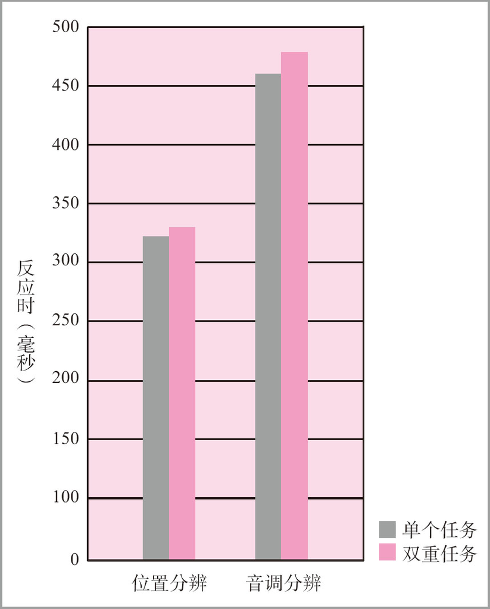

图3.22 由舒马赫等所做的显示完全时间分享的实验。柱状图表示执行两个任务，位置分辨和音调分辨所需的时间，包括了单独执行每个任务本身所需的时间和同时执行这两个任务所需的时间。执行任务的时间几乎未受到需要同时执行两个任务的影响。这表明被试几乎实现了完全时间分享。 （资料来源：Schumacher et al.，2001 Reprinted by the permission of the publisher．© 2001 by Psychological Science .）

图3.23是对舒马赫等人（Schumacher et al.，2001）的实验中所出现情况的分析。图中显示了如下五个加工过程中各时间点所发生的情况：（1）觉察到字母的视觉位置，（2）产生手动动作，（3）中枢认知，（4）觉察到听觉刺激，以及（5）产生言语。任务1包括：对字母的位置进行视觉编码，通过中枢认知选择用哪个手指按键，然后执行手指的实际动作。任务2包括：觉察到声音并对它编码，通过中枢认知选择要说哪个词（“1”，“2”或“3”），然后，生成这个词并说出这个词。图3.23中方框的长度代表根据对人的表现研究所估算的每个部分所持续的时间。每个加工过程都能与其他加工过程平行执行。譬如说，在觉察到声音并对它编码期间，对字母位置进行了编码（它比对声音编码快得多），中枢认知选择了手指，运动系统开始安排动作。虽然所有加工过程都能平行进行，但是在每个加工过程内，一次只能做一件事。这就使得中枢认知过程存在一个潜在的问题，因为中枢认知必须指挥所有的活动。在这个例子中，中枢认知既要为任务1又要为任务2服务。然而在这项实验中，花费在中枢认知的时间是如此短暂以至于两个任务不必竞争这一资源。在这个实验中，五天的练习对于减少花费在中枢认知上的时间起到了关键作用。

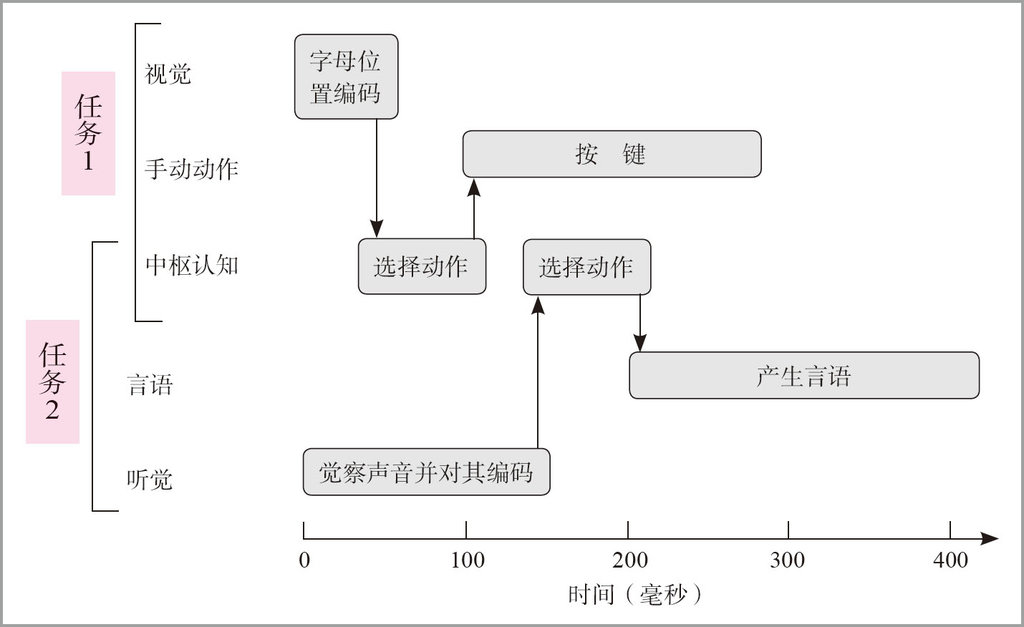

图3.23 对舒马赫等人（Schumacher et al.，2001）的双重任务实验中的五个加工过程的时间分析：（1）视觉，（2）手动，（3）中枢认知，（4）言语，以及（5）听觉。

尽管此处的讨论集中在中枢认知中的瓶颈问题上，但是任何感觉通道都可能存在着瓶颈。人们不可能同时注意两个位置。前面我们讨论过的证据说明，如果人们必须注意一个以上的位置，那么他们必须将注意逐次转移至视觉阵列中的各个位置上。类似地，人们一次只能加工一个言语流，一次只能用一种方式移动双手，或者一次只能说一件事。虽然所有这些外围加工都有瓶颈，但是一般认为中枢认知中的瓶颈能够有最大的影响，并且这些就是我们很少发现自己在同时思考两件事的原因。这种中枢认知中的瓶颈被称为中枢瓶颈 （central bottleneck）。

◎人们能够同时加工多种知觉通道的信息或者同时完成多种运动系统的动作，但是他们无法在单一系统中同时加工多件事情，包括中枢认知系统。

### 启示

#### 为什么边开车边使用手机是危险的行为

信息加工的瓶颈有着重要的实际应用意义。根据哈佛风险分析中心的一项研究统计（Cohen & Graham，2003），手机分散注意力导致美国每年有2 600人死亡，330000人受伤，以及150万人蒙受财产损失。斯特雷耶和德鲁斯（Strayer & Drews，2007）综述了人们在使用手机时更可能看不到交通灯和其他关键信息的证据。并且，即使借助手机免提功能，这些问题也不能得到任何改善。然而，听收音机或有声读物却不会干扰驾驶。斯特雷耶和德鲁斯认为，参与谈话需要更多的中枢认知功能。当一个人用手机讲某事时，他期待着对方的回应而忽略了行驶状况。斯特雷耶和德鲁斯还提出，和车上的乘客谈话并不会分散太多的注意，因为乘客会根据行驶情况调整谈话，甚至指出司机可能面临的问题。

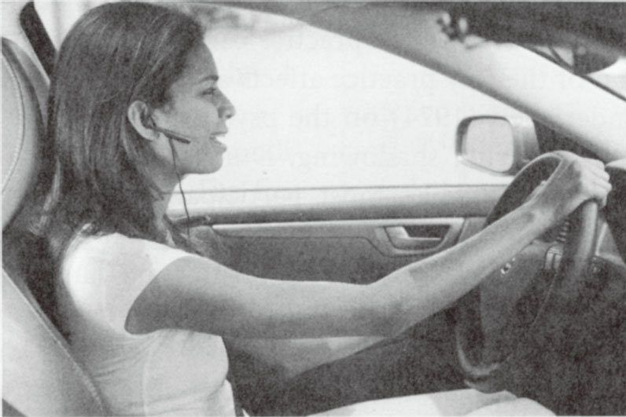

### 自动化：通过练习而精通

在第9章，我们将详细地讨论人们如何通过练习成为专家。练习的总效果是减少信息加工的中枢认知部分。当一个人对一个任务的中枢认知部分进行了大量的练习，以致于在执行这个任务时很少甚至不需要思考时，我们就说执行这个任务已经自动化了。自动化 （automaticity）是个程度问题。驾驶汽车就是一个很好的例子。有经验的司机在正常的路面情况下开车已经变得高度自动化，以致于他们能够一边谈话一边毫不费力地开车。他们能很成功地边开车边执行像给收音机换台这样的次要任务（Wikman，Nieminen，& Summala，1998）。他们也时常会有在高速路上行驶了很长一段却不记得自己在这期间做过什么的体验。

在心理学文献中有许多引人注目的关于练习如何实现平行加工的例子。其中一个关于练习影响注意限度的例子是安德伍德（Underwood，1974）报告的对心理学家内维尔·莫里（Neville Moray）的研究，莫里花了多年时间来进行追踪研究 <sup>(7)</sup> 。在这期间，莫里对追踪做了大量的练习。与实验中的大多数被试不同，他能够很好地报告出非注意通道中包含什么。经过大量的练习，莫里已经部分地实现了追踪加工的自动化，使他有能力来注意未被追踪的通道。

斯佩克等人（Spelke，Hirst，& Neisser，1976）提供了一个有趣的例证来说明经过大量练习的技能如何不再妨碍其他正在进行的行为。（这是由当时还在哈佛大学的作家格特鲁德·斯坦（Gertrude Stein）最早提出的一个例证的后续研究。）他们的被试必须执行两项任务：默读并理解一段课文，同时听写主试口述的词汇。起初，同时执行这两项任务相当困难。被试的阅读要比正常情况慢得多。然而，经过六周的练习后，被试便能以正常速度阅读了。他们变得十分熟练，以致于他们的理解成绩与正常阅读时一样好。对于这些被试来说，边阅读边听写已经变得不比边阅读边走路困难多少。有意思的是，被试报告他们并没有意识到自己在听写些什么。就像开车一样，被试并不会去注意自己的自动化行为。 <sup>(8)</sup>

另一个自动化的例子是按文本打字。打字员在阅读文本的同时用手指击键打字。在这种情况下，我们有三个系统在平行加工：感知所要打的字，中枢认知系统将先前已经感知到的字母转换成相应的击键指令，以及手指实际打出早先感知到的字母。熟练的打字员经常报告说他们很少意识到自己在打些什么，因为执行这些任务已经变得高度自动化了。熟练的打字员还发现，要立即停止打字是不可能的。当突然要他们停下来的时候，他们要再打几个字母才会停住（Salthouse，1985，1986）。

◎随着对任务的熟练，执行它们会变得越发自动化，对中枢认知的需求越来越少。

### 斯特鲁普效应

自动化加工不仅只需要较少的中枢认知，甚至不需要中枢认知，而且似乎还很难阻止。一个很好的例子就是熟练的读者对单词的识别。让他们看一个常见词而不去解读它几乎是不可能的。这种对词汇自动识别的强烈倾向性，在被称为斯特鲁普效应 <sup>(9)</sup> （Stroop effect）的现象中得到了研究。这个现象的命名是因为最早报告它的是心理学家J·里德利·斯特鲁普（J．Ridley Stroop，1935）。实验任务是要求被试说出印刷单词的墨水的颜色。彩色插页3.2中有这种任务的演示。试着尽快说出每列单词的颜色，哪一列是最容易说出的？哪一列是最难的？

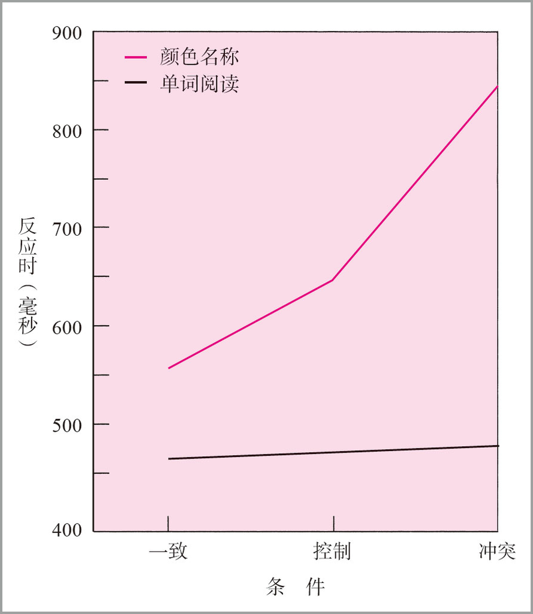

图3.24 标准斯特鲁普任务的行为数据。曲线表示的是被试的平均反应时。它是测试条件的函数：一致（单词是印刷这个词所用墨水的颜色名称）；控制（单词与颜色完全无关）和冲突（单词是指与印刷这个词所用墨水的颜色不同的颜色名称）。 （资料来源：Dunbar & MacLeod，1984．Reprinted by permission of the publisher．© 1984 by the Journal of Experimental Psychology：Human Perception and Performance .）。

图中三列单词展示了斯特鲁普效应研究中涉及的三种情况。第一列是中性或控制条件，其中的单词不含有表示颜色的单词。第二列是一致条件，也就是单词的颜色与其所表示的颜色相同。第三列是冲突条件，即单词的颜色与其所表示的颜色不同。在现代的典型实验中，不会让被试读整列单词，而是一次只呈现一个单词，测量被试说出单词的颜色的反应时。图3.24给出了由邓巴和麦克劳德（Dunbar & MacLeod，1984）所做的一项斯特鲁普效应实验。与作为控制条件的中性词相比，在一致的条件下，也就是单词就是墨水的颜色时，被试命名墨水的颜色稍微快一些。在冲突的条件下，即当单词是指与墨水颜色不同的颜色时，他们命名墨水颜色要慢得多。例如，当被试看到用绿色的墨水印出的单词red（红）时，他们感到说green（绿）十分困难。从图3.24中还可以看到，当任务转换成要求被试读出单词而不是说出颜色时的结果。这种效应是不对称的，也就是，当被试阅读单词时，受到的来自所用墨水颜色的干扰很小。这反映出阅读的高度自动化。关于这种自动化的另外一个证据是，被试阅读单词比他们命名印刷单词的墨水的颜色要快得多。阅读是一个如此高度自动化的过程，它不仅不会受颜色的影响，而且被试通常很难阻止自己读这个单词，并因为读这个单词而干扰颜色命名。

麦克劳德和邓巴（MacLeod & Dunbar，1988）考察了练习对斯特鲁普任务中的表现的影响。在实验中，他们让被试学习随机的几何图形所对应的颜色名称。彩色插页3.2中（a）显示了被试学习的图形–颜色配对的例子。主试接下来向被试呈现测试用的图形，要求他们或者说出与该图形对应的颜色名称（图形命名），或者说出这个图形本身的颜色（颜色命名） <sup>(10)</sup> 。正如原始的斯特鲁普实验那样，存在三种情况，如彩色插页3.3（b）所示：

1. 一致：随机图形对应的颜色名与图形本身的颜色相同。
2. 控制：当要求被试说出图形所对应的颜色名时，图形是白色的；当要求被试说出图形实际的颜色时，图形为彩色长方形。（长方形不对应任何颜色。）
3. 冲突：随机图形对应的颜色名与图形本身的颜色不同。

图3.25为实验结果。颜色命名比图形命名的自动化程度要高得多，图形本身的颜色与图形对应的颜色名是否一致，对颜色命名影响不大，而对图形命名则有明显影响（参见图3.25a）。然后麦克劳德和邓巴让被试接受20天图形命名训练。被试命名图形的速度快了很多，不再受颜色命名干扰，并且反过来对颜色命名造成了干扰（参见图3.25b）。因此，训练的效果是使图形命名实现了自动化，就像阅读单词那样，结果造成了对颜色命名的干扰。

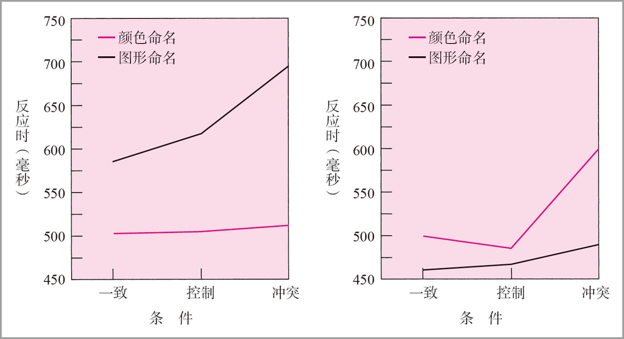

图3.25 麦克劳德和邓巴（1988）所做的考察练习对斯特鲁普任务中表现的影响的实验结果。报告的数据是图形命名和颜色命名所需的平均时间，它是颜色-图形一致性的函数：（a）初始表现；（b）练习20天后的表现。练习使得图形命名实现了自动化，就像阅读单词那样，以致于对颜色命名造成了干扰。

◎阅读单词是如此高度自动化的过程以至于难以抑制，这将对加工单词的其他信息造成干扰。